# Identify_Customer_Segments-FinalV

### Prerequsite - Upgrade Scikit Learn

```python
import sklearn
print('The scikit-learn version is {}.'.format(sklearn.__version__))
```

```
The scikit-learn version is 1.3.0.
```

```python
import os
os.environ['PATH'] = f"{os.environ['PATH']}:/root/.local/bin"
```

Restart the Kernel.

```python
!python -m pip install --upgrade scikit-learn
import sklearn
print('The scikit-learn version is {}.'.format(sklearn.__version__))
```

```
The scikit-learn version is 1.3.0.
```

```python
from sklearn.preprocessing import OneHotEncoder
from sklearn.preprocessing import StandardScaler
```

# Project: Identify Customer Segments

In this project, you will apply unsupervised learning techniques to identify segments of the population that form the core customer base for a mail-order sales company in Germany. These segments can then be used to direct marketing campaigns towards audiences that will have the highest expected rate of returns. The data that you will use has been provided by our partners at Bertelsmann Arvato Analytics, and represents a real-life data science task.

This notebook will help you complete this task by providing a framework within which you will perform your analysis steps. In each step of the project, you will see some text describing the subtask that you will perform, followed by one or more code cells for you to complete your work. **Feel free to add additional code and markdown cells as you go along so that you can explore everything in precise chunks.** The code cells provided in the base template will outline only the major tasks, and will usually not be enough to cover all of the minor tasks that comprise it.

It should be noted that while there will be precise guidelines on how you should handle certain tasks in the project, there will also be places where an exact specification is not provided. **There will be times in the project where you will need to make and justify your own decisions on how to treat the data.** These are places where there may not be only one way to handle the data. In real-life tasks, there may be many valid ways to approach an analysis task. One of the most important things you can do is clearly document your approach so that other scientists can understand the decisions you've made.

At the end of most sections, there will be a Markdown cell labeled **Discussion**. In these cells, you will report your findings for the completed section, as well as document the decisions that you made in your approach to each subtask. **Your project will be evaluated not just on the code used to complete the tasks outlined, but also your communication about your observations and conclusions at each stage.**

```python
# import libraries here; add more as necessary
import numpy as np
import pandas as pd
import matplotlib.pyplot as plt
import seaborn as sns
from sklearn.decomposition import PCA
from sklearn.cluster import KMeans

# magic word for producing visualizations in notebook
%matplotlib inline

'''
Import note: The classroom currently uses sklearn version 0.19.
If you need to use an imputer, it is available in sklearn.preprocessing.Imputer,
instead of sklearn.impute as in newer versions of sklearn.
'''
pd.options.display.max_rows = None
pd.options.display.max_columns = None
```

### Step 0: Load the Data

Each row of the demographics files represents a single person, but also includes information outside of individuals, including information about their household, building, and neighborhood. You will use this information to cluster the general population into groups with similar demographic properties. Then, you will see how the people in the customers dataset fit into those created clusters. The hope here is that certain clusters are over-represented in the customers data, as compared to the general population; those over-represented clusters will be assumed to be part of the core userbase. This information can then be used for further applications, such as targeting for a marketing campaign.

To start off with, load in the demographics data for the general population into a pandas DataFrame, and do the same for the feature attributes summary. Note for all of the `.csv` data files in this project: they're semicolon (`;`) delimited, so you'll need an additional argument in your [`read_csv()`](https://pandas.pydata.org/pandas-docs/stable/generated/pandas.read_csv.html) call to read in the data properly. Also, considering the size of the main dataset, it may take some time for it to load completely.

Once the dataset is loaded, it's recommended that you take a little bit of time just browsing the general structure of the dataset and feature summary file. You'll be getting deep into the innards of the cleaning in the first major step of the project, so gaining some general familiarity can help you get your bearings.

```python
# Load in the general demographics data.
AZDIAS= pd.read_csv("Udacity_AZDIAS_Subset2.csv", sep=';')
# Load in the feature summary file.
AZDIAS_Feature= pd.read_csv("AZDIAS_Feature_Summary.csv", sep=';')
# Load customer base for a mail-order sales company in Germany data.
CUSTOMERS= pd.read_csv("Udacity_CUSTOMERS_Subset.csv", sep=';')
```

```python
#Start with general demographics data
#sample of rows for the data set
AZDIAS.head(5)
```

|  | AGER_TYP | ALTERSKATEGORIE_GROB | ANREDE_KZ | CJT_GESAMTTYP | FINANZ_MINIMALIST | FINANZ_SPARER | FINANZ_VORSORGER | FINANZ_ANLEGER | FINANZ_UNAUFFAELLIGER | FINANZ_HAUSBAUER | FINANZTYP | GEBURTSJAHR | GFK_URLAUBERTYP | GREEN_AVANTGARDE | HEALTH_TYP | LP_LEBENSPHASE_FEIN | LP_LEBENSPHASE_GROB | LP_FAMILIE_FEIN | LP_FAMILIE_GROB | LP_STATUS_FEIN | LP_STATUS_GROB | NATIONALITAET_KZ | PRAEGENDE_JUGENDJAHRE | RETOURTYP_BK_S | SEMIO_SOZ | SEMIO_FAM | SEMIO_REL | SEMIO_MAT | SEMIO_VERT | … |
| --- | --- | --- | --- | --- | --- | --- | --- | --- | --- | --- | --- | --- | --- | --- | --- | --- | --- | --- | --- | --- | --- | --- | --- | --- | --- | --- | --- | --- | --- | --- |
| 0 | -1 | 2 | 1 | 2.0 | 3 | 4 | 3 | 5 | 5 | 3 | 4 | 0 | 10.0 | 0 | -1 | 15.0 | 4.0 | 2.0 | 2.0 | 1.0 | 1.0 | 0 | 0 | 5.0 | 2 | 6 | 7 | 5 | 1 | … |
| 1 | -1 | 1 | 2 | 5.0 | 1 | 5 | 2 | 5 | 4 | 5 | 1 | 1996 | 10.0 | 0 | 3 | 21.0 | 6.0 | 5.0 | 3.0 | 2.0 | 1.0 | 1 | 14 | 1.0 | 5 | 4 | 4 | 3 | 1 | … |
| 2 | -1 | 3 | 2 | 3.0 | 1 | 4 | 1 | 2 | 3 | 5 | 1 | 1979 | 10.0 | 1 | 3 | 3.0 | 1.0 | 1.0 | 1.0 | 3.0 | 2.0 | 1 | 15 | 3.0 | 4 | 1 | 3 | 3 | 4 | … |
| 3 | 2 | 4 | 2 | 2.0 | 4 | 2 | 5 | 2 | 1 | 2 | 6 | 1957 | 1.0 | 0 | 2 | 0.0 | 0.0 | 0.0 | 0.0 | 9.0 | 4.0 | 1 | 8 | 2.0 | 5 | 1 | 2 | 1 | 4 | … |
| 4 | -1 | 3 | 1 | 5.0 | 4 | 3 | 4 | 1 | 3 | 2 | 5 | 1963 | 5.0 | 0 | 3 | 32.0 | 10.0 | 10.0 | 5.0 | 3.0 | 2.0 | 1 | 8 | 5.0 | 6 | 4 | 4 | 2 | 7 | … |

```python
shape1= AZDIAS.shape
print("(Row_num, Column_num)= {}".format(shape1))
```

```
(Row_num, Column_num)= (891221, 85)
```

```python
#It helps us find out if there are missing values and the type of the features
AZDIAS.info()
```

```
<class 'pandas.core.frame.DataFrame'>
RangeIndex: 891221 entries, 0 to 891220
Data columns (total 85 columns):
 #   Column                 Non-Null Count   Dtype
---  ------                 --------------   -----
 0   AGER_TYP               891221 non-null  int64
 1   ALTERSKATEGORIE_GROB   891221 non-null  int64
 2   ANREDE_KZ              891221 non-null  int64
 3   CJT_GESAMTTYP          886367 non-null  float64
 4   FINANZ_MINIMALIST      891221 non-null  int64
 5   FINANZ_SPARER          891221 non-null  int64
 6   FINANZ_VORSORGER       891221 non-null  int64
 7   FINANZ_ANLEGER         891221 non-null  int64
 8   FINANZ_UNAUFFAELLIGER  891221 non-null  int64
 9   FINANZ_HAUSBAUER       891221 non-null  int64
```

[output cut: 77 more lines]

```python
#some summary statistics for numerical features,
#in additional “count” is the number of non-missing values in each features.
AZDIAS.describe()
```

|  | AGER_TYP | ALTERSKATEGORIE_GROB | ANREDE_KZ | CJT_GESAMTTYP | FINANZ_MINIMALIST | FINANZ_SPARER | FINANZ_VORSORGER | FINANZ_ANLEGER | FINANZ_UNAUFFAELLIGER | FINANZ_HAUSBAUER | FINANZTYP | GEBURTSJAHR | GFK_URLAUBERTYP | GREEN_AVANTGARDE | HEALTH_TYP | LP_LEBENSPHASE_FEIN | LP_LEBENSPHASE_GROB | LP_FAMILIE_FEIN | LP_FAMILIE_GROB | LP_STATUS_FEIN | LP_STATUS_GROB | NATIONALITAET_KZ | PRAEGENDE_JUGENDJAHRE | RETOURTYP_BK_S | SEMIO_SOZ | SEMIO_FAM | SEMIO_REL | SEMIO_MAT | SEMIO_VERT | … |
| --- | --- | --- | --- | --- | --- | --- | --- | --- | --- | --- | --- | --- | --- | --- | --- | --- | --- | --- | --- | --- | --- | --- | --- | --- | --- | --- | --- | --- | --- | --- |
| count | 891221.000000 | 891221.000000 | 891221.000000 | 886367.000000 | 891221.000000 | 891221.000000 | 891221.000000 | 891221.000000 | 891221.000000 | 891221.000000 | 891221.000000 | 891221.000000 | 886367.000000 | 891221.000000 | 891221.000000 | 886367.000000 | 886367.000000 | 886367.000000 | 886367.000000 | 886367.000000 | 886367.000000 | 891221.000000 | 891221.000000 | 886367.000000 | 891221.000000 | 891221.000000 | 891221.000000 | 891221.000000 | 891221.000000 | … |
| mean | -0.358435 | 2.777398 | 1.522098 | 3.632838 | 3.074528 | 2.821039 | 3.401106 | 3.033328 | 2.874167 | 3.075121 | 3.790586 | 1101.178533 | 7.350304 | 0.196612 | 1.792102 | 14.622637 | 4.453621 | 3.599574 | 2.185966 | 4.791151 | 2.432575 | 1.026827 | 8.154346 | 3.419630 | 3.945860 | 4.272729 | 4.240609 | 4.001597 | 4.023709 | … |
| std | 1.198724 | 1.068775 | 0.499512 | 1.595021 | 1.321055 | 1.464749 | 1.322134 | 1.529603 | 1.486731 | 1.353248 | 1.987876 | 976.583551 | 3.525723 | 0.397437 | 1.269062 | 12.616883 | 3.855639 | 3.926486 | 1.756537 | 3.425305 | 1.474315 | 0.586634 | 4.844532 | 1.417741 | 1.946564 | 1.915885 | 2.007373 | 1.857540 | 2.077746 | … |
| min | -1.000000 | 1.000000 | 1.000000 | 1.000000 | 1.000000 | 1.000000 | 1.000000 | 1.000000 | 1.000000 | 1.000000 | 1.000000 | 0.000000 | 1.000000 | 0.000000 | -1.000000 | 0.000000 | 0.000000 | 0.000000 | 0.000000 | 1.000000 | 1.000000 | 0.000000 | 0.000000 | 1.000000 | 1.000000 | 1.000000 | 1.000000 | 1.000000 | 1.000000 | … |
| 25% | -1.000000 | 2.000000 | 1.000000 | 2.000000 | 2.000000 | 1.000000 | 3.000000 | 2.000000 | 2.000000 | 2.000000 | 2.000000 | 0.000000 | 5.000000 | 0.000000 | 1.000000 | 4.000000 | 1.000000 | 1.000000 | 1.000000 | 2.000000 | 1.000000 | 1.000000 | 5.000000 | 2.000000 | 2.000000 | 3.000000 | 3.000000 | 2.000000 | 2.000000 | … |
| 50% | -1.000000 | 3.000000 | 2.000000 | 4.000000 | 3.000000 | 3.000000 | 3.000000 | 3.000000 | 3.000000 | 3.000000 | 4.000000 | 1943.000000 | 8.000000 | 0.000000 | 2.000000 | 11.000000 | 3.000000 | 1.000000 | 1.000000 | 4.000000 | 2.000000 | 1.000000 | 8.000000 | 3.000000 | 4.000000 | 4.000000 | 4.000000 | 4.000000 | 4.000000 | … |
| 75% | -1.000000 | 4.000000 | 2.000000 | 5.000000 | 4.000000 | 4.000000 | 5.000000 | 5.000000 | 4.000000 | 4.000000 | 6.000000 | 1970.000000 | 10.000000 | 0.000000 | 3.000000 | 27.000000 | 8.000000 | 8.000000 | 4.000000 | 9.000000 | 4.000000 | 1.000000 | 14.000000 | 5.000000 | 6.000000 | 6.000000 | 6.000000 | 5.000000 | 6.000000 | … |
| max | 3.000000 | 9.000000 | 2.000000 | 6.000000 | 5.000000 | 5.000000 | 5.000000 | 5.000000 | 5.000000 | 5.000000 | 6.000000 | 2017.000000 | 12.000000 | 1.000000 | 3.000000 | 40.000000 | 12.000000 | 11.000000 | 5.000000 | 10.000000 | 5.000000 | 3.000000 | 15.000000 | 5.000000 | 7.000000 | 7.000000 | 7.000000 | 7.000000 | 7.000000 | … |

```python
#the count of unique features.
AZDIAS.count()
```

```
AGER_TYP                 891221
ALTERSKATEGORIE_GROB     891221
ANREDE_KZ                891221
CJT_GESAMTTYP            886367
FINANZ_MINIMALIST        891221
FINANZ_SPARER            891221
FINANZ_VORSORGER         891221
FINANZ_ANLEGER           891221
FINANZ_UNAUFFAELLIGER    891221
FINANZ_HAUSBAUER         891221
FINANZTYP                891221
GEBURTSJAHR              891221
GFK_URLAUBERTYP          886367
GREEN_AVANTGARDE         891221
HEALTH_TYP               891221
LP_LEBENSPHASE_FEIN      886367
LP_LEBENSPHASE_GROB      886367
LP_FAMILIE_FEIN          886367
LP_FAMILIE_GROB          886367
LP_STATUS_FEIN           886367
LP_STATUS_GROB           886367
NATIONALITAET_KZ         891221
PRAEGENDE_JUGENDJAHRE    891221
RETOURTYP_BK_S           886367
SEMIO_SOZ                891221
SEMIO_FAM                891221
SEMIO_REL                891221
SEMIO_MAT                891221
SEMIO_VERT               891221
SEMIO_LUST               891221
SEMIO_ERL                891221
SEMIO_KULT               891221
SEMIO_RAT                891221
SEMIO_KRIT               891221
SEMIO_DOM                891221
SEMIO_KAEM               891221
SEMIO_PFLICHT            891221
SEMIO_TRADV              891221
SHOPPER_TYP              891221
SOHO_KZ                  817722
```

[output cut: 31 more lines]

```
MOBI_REGIO               757897
ONLINE_AFFINITAET        886367
REGIOTYP                 770025
KBA13_ANZAHL_PKW         785421
PLZ8_ANTG1               774706
PLZ8_ANTG2               774706
PLZ8_ANTG3               774706
PLZ8_ANTG4               774706
PLZ8_BAUMAX              774706
PLZ8_HHZ                 774706
PLZ8_GBZ                 774706
ARBEIT                   794005
ORTSGR_KLS9              794005
RELAT_AB                 794005
dtype: int64
```

```python
#Second feature summary
#sample of rows for the data set
AZDIAS_Feature.head(7)
```

|  | attribute | information_level | type | missing_or_unknown |
| --- | --- | --- | --- | --- |
| 0 | AGER_TYP | person | categorical | [-1,0] |
| 1 | ALTERSKATEGORIE_GROB | person | ordinal | [-1,0,9] |
| 2 | ANREDE_KZ | person | categorical | [-1,0] |
| 3 | CJT_GESAMTTYP | person | categorical | [0] |
| 4 | FINANZ_MINIMALIST | person | ordinal | [-1] |
| 5 | FINANZ_SPARER | person | ordinal | [-1] |
| 6 | FINANZ_VORSORGER | person | ordinal | [-1] |

```python
shape2= AZDIAS_Feature.shape
print("(Row_num, Column_num)= {}".format(shape2))
```

```
(Row_num, Column_num)= (85, 4)
```

```python
AZDIAS_Feature.info()
```

```
<class 'pandas.core.frame.DataFrame'>
RangeIndex: 85 entries, 0 to 84
Data columns (total 4 columns):
 #   Column              Non-Null Count  Dtype
---  ------              --------------  -----
 0   attribute           85 non-null     object
 1   information_level   85 non-null     object
 2   type                85 non-null     object
 3   missing_or_unknown  85 non-null     object
dtypes: object(4)
memory usage: 2.8+ KB
```

```python
AZDIAS_Feature.describe()
```

|  | attribute | information_level | type | missing_or_unknown |
| --- | --- | --- | --- | --- |
| count | 85 | 85 | 85 | 85 |
| unique | 85 | 9 | 5 | 9 |
| top | AGER_TYP | person | ordinal | [-1] |
| freq | 1 | 43 | 49 | 26 |

```python
AZDIAS_Feature.count()
```

```
attribute             85
information_level     85
type                  85
missing_or_unknown    85
dtype: int64
```

```python
#Third customer base for a mail-order sales company in Germany data
#sample of rows for the data set
CUSTOMERS.head(5)
```

|  | AGER_TYP | ALTERSKATEGORIE_GROB | ANREDE_KZ | CJT_GESAMTTYP | FINANZ_MINIMALIST | FINANZ_SPARER | FINANZ_VORSORGER | FINANZ_ANLEGER | FINANZ_UNAUFFAELLIGER | FINANZ_HAUSBAUER | FINANZTYP | GEBURTSJAHR | GFK_URLAUBERTYP | GREEN_AVANTGARDE | HEALTH_TYP | LP_LEBENSPHASE_FEIN | LP_LEBENSPHASE_GROB | LP_FAMILIE_FEIN | LP_FAMILIE_GROB | LP_STATUS_FEIN | LP_STATUS_GROB | NATIONALITAET_KZ | PRAEGENDE_JUGENDJAHRE | RETOURTYP_BK_S | SEMIO_SOZ | SEMIO_FAM | SEMIO_REL | SEMIO_MAT | SEMIO_VERT | … |
| --- | --- | --- | --- | --- | --- | --- | --- | --- | --- | --- | --- | --- | --- | --- | --- | --- | --- | --- | --- | --- | --- | --- | --- | --- | --- | --- | --- | --- | --- | --- |
| 0 | 2 | 4 | 1 | 5.0 | 5 | 1 | 5 | 1 | 2 | 2 | 2 | 0 | 4.0 | 1 | 1 | 20.0 | 5.0 | 2.0 | 2.0 | 10.0 | 5.0 | 1 | 4 | 5.0 | 6 | 5 | 2 | 6 | 6 | … |
| 1 | -1 | 4 | 1 | NaN | 5 | 1 | 5 | 1 | 3 | 2 | 2 | 0 | NaN | 0 | 1 | NaN | NaN | NaN | NaN | NaN | NaN | 1 | 0 | NaN | 3 | 6 | 2 | 6 | 7 | … |
| 2 | -1 | 4 | 2 | 2.0 | 5 | 1 | 5 | 1 | 4 | 4 | 2 | 0 | 3.0 | 1 | 2 | 13.0 | 3.0 | 1.0 | 1.0 | 10.0 | 5.0 | 1 | 4 | 5.0 | 2 | 2 | 1 | 3 | 3 | … |
| 3 | 1 | 4 | 1 | 2.0 | 5 | 1 | 5 | 2 | 1 | 2 | 6 | 0 | 10.0 | 0 | 2 | 0.0 | 0.0 | 0.0 | 0.0 | 9.0 | 4.0 | 1 | 1 | 3.0 | 6 | 5 | 3 | 4 | 7 | … |
| 4 | -1 | 3 | 1 | 6.0 | 3 | 1 | 4 | 4 | 5 | 2 | 2 | 1960 | 2.0 | 0 | 3 | 31.0 | 10.0 | 10.0 | 5.0 | 1.0 | 1.0 | 1 | 8 | 5.0 | 4 | 5 | 4 | 6 | 5 | … |

```python
shape3= CUSTOMERS.shape
print("(Row_num, Column_num)= {}".format(shape3))
```

```
(Row_num, Column_num)= (191652, 85)
```

```python
CUSTOMERS.info()
```

```
<class 'pandas.core.frame.DataFrame'>
RangeIndex: 191652 entries, 0 to 191651
Data columns (total 85 columns):
 #   Column                 Non-Null Count   Dtype
---  ------                 --------------   -----
 0   AGER_TYP               191652 non-null  int64
 1   ALTERSKATEGORIE_GROB   191652 non-null  int64
 2   ANREDE_KZ              191652 non-null  int64
 3   CJT_GESAMTTYP          188439 non-null  float64
 4   FINANZ_MINIMALIST      191652 non-null  int64
 5   FINANZ_SPARER          191652 non-null  int64
 6   FINANZ_VORSORGER       191652 non-null  int64
 7   FINANZ_ANLEGER         191652 non-null  int64
 8   FINANZ_UNAUFFAELLIGER  191652 non-null  int64
 9   FINANZ_HAUSBAUER       191652 non-null  int64
```

[output cut: 77 more lines]

```python
CUSTOMERS.describe()
```

|  | AGER_TYP | ALTERSKATEGORIE_GROB | ANREDE_KZ | CJT_GESAMTTYP | FINANZ_MINIMALIST | FINANZ_SPARER | FINANZ_VORSORGER | FINANZ_ANLEGER | FINANZ_UNAUFFAELLIGER | FINANZ_HAUSBAUER | FINANZTYP | GEBURTSJAHR | GFK_URLAUBERTYP | GREEN_AVANTGARDE | HEALTH_TYP | LP_LEBENSPHASE_FEIN | LP_LEBENSPHASE_GROB | LP_FAMILIE_FEIN | LP_FAMILIE_GROB | LP_STATUS_FEIN | LP_STATUS_GROB | NATIONALITAET_KZ | PRAEGENDE_JUGENDJAHRE | RETOURTYP_BK_S | SEMIO_SOZ | SEMIO_FAM | SEMIO_REL | SEMIO_MAT | SEMIO_VERT | … |
| --- | --- | --- | --- | --- | --- | --- | --- | --- | --- | --- | --- | --- | --- | --- | --- | --- | --- | --- | --- | --- | --- | --- | --- | --- | --- | --- | --- | --- | --- | --- |
| count | 191652.000000 | 191652.000000 | 191652.000000 | 188439.000000 | 191652.000000 | 191652.000000 | 191652.000000 | 191652.000000 | 191652.000000 | 191652.000000 | 191652.000000 | 191652.000000 | 188439.000000 | 191652.000000 | 191652.000000 | 188439.000000 | 188439.000000 | 188439.000000 | 188439.000000 | 188439.000000 | 188439.000000 | 191652.000000 | 191652.000000 | 188439.000000 | 191652.000000 | 191652.000000 | 191652.000000 | 191652.000000 | 191652.000000 | … |
| mean | 0.344359 | 3.060907 | 1.376432 | 3.677928 | 3.963773 | 2.057051 | 4.183317 | 2.439808 | 2.646176 | 2.781176 | 4.137958 | 1003.392733 | 6.302268 | 0.367171 | 1.198396 | 18.181571 | 5.422694 | 4.254448 | 2.355043 | 6.687910 | 3.209251 | 0.773433 | 4.248273 | 3.716311 | 3.742137 | 4.414026 | 4.112788 | 3.883163 | 4.185279 | … |
| std | 1.391672 | 1.086254 | 0.484492 | 1.813975 | 1.036230 | 1.319422 | 0.995365 | 1.697932 | 1.586506 | 1.147353 | 1.503946 | 974.531081 | 2.877181 | 0.482035 | 1.450937 | 15.009985 | 4.717907 | 4.492807 | 2.052142 | 3.090573 | 1.436958 | 0.495983 | 3.807671 | 1.113933 | 1.718039 | 1.733128 | 2.070958 | 1.840131 | 2.367407 | … |
| min | -1.000000 | 1.000000 | 1.000000 | 1.000000 | 1.000000 | 1.000000 | 1.000000 | 1.000000 | 1.000000 | 1.000000 | 1.000000 | 0.000000 | 1.000000 | 0.000000 | -1.000000 | 0.000000 | 0.000000 | 0.000000 | 0.000000 | 1.000000 | 1.000000 | 0.000000 | 0.000000 | 1.000000 | 1.000000 | 1.000000 | 1.000000 | 1.000000 | 1.000000 | … |
| 25% | -1.000000 | 3.000000 | 1.000000 | 2.000000 | 3.000000 | 1.000000 | 3.000000 | 1.000000 | 1.000000 | 2.000000 | 2.000000 | 0.000000 | 5.000000 | 0.000000 | -1.000000 | 0.000000 | 0.000000 | 0.000000 | 0.000000 | 5.000000 | 2.000000 | 0.000000 | 0.000000 | 3.000000 | 2.000000 | 3.000000 | 2.000000 | 2.000000 | 1.000000 | … |
| 50% | 0.000000 | 3.000000 | 1.000000 | 4.000000 | 4.000000 | 1.000000 | 5.000000 | 2.000000 | 2.000000 | 3.000000 | 4.000000 | 1926.000000 | 5.000000 | 0.000000 | 2.000000 | 16.000000 | 4.000000 | 2.000000 | 2.000000 | 7.000000 | 3.000000 | 1.000000 | 4.000000 | 3.000000 | 3.000000 | 5.000000 | 4.000000 | 4.000000 | 5.000000 | … |
| 75% | 2.000000 | 4.000000 | 2.000000 | 6.000000 | 5.000000 | 4.000000 | 5.000000 | 5.000000 | 5.000000 | 3.000000 | 5.000000 | 1949.000000 | 9.000000 | 1.000000 | 2.000000 | 36.000000 | 12.000000 | 10.000000 | 5.000000 | 10.000000 | 5.000000 | 1.000000 | 6.000000 | 5.000000 | 6.000000 | 6.000000 | 7.000000 | 5.000000 | 6.000000 | … |
| max | 3.000000 | 9.000000 | 2.000000 | 6.000000 | 5.000000 | 5.000000 | 5.000000 | 5.000000 | 5.000000 | 5.000000 | 6.000000 | 2017.000000 | 12.000000 | 1.000000 | 3.000000 | 40.000000 | 12.000000 | 11.000000 | 5.000000 | 10.000000 | 5.000000 | 3.000000 | 15.000000 | 5.000000 | 7.000000 | 7.000000 | 7.000000 | 7.000000 | 7.000000 | … |

```python
CUSTOMERS.count()
```

```
AGER_TYP                 191652
ALTERSKATEGORIE_GROB     191652
ANREDE_KZ                191652
CJT_GESAMTTYP            188439
FINANZ_MINIMALIST        191652
FINANZ_SPARER            191652
FINANZ_VORSORGER         191652
FINANZ_ANLEGER           191652
FINANZ_UNAUFFAELLIGER    191652
FINANZ_HAUSBAUER         191652
FINANZTYP                191652
GEBURTSJAHR              191652
GFK_URLAUBERTYP          188439
GREEN_AVANTGARDE         191652
HEALTH_TYP               191652
LP_LEBENSPHASE_FEIN      188439
LP_LEBENSPHASE_GROB      188439
LP_FAMILIE_FEIN          188439
LP_FAMILIE_GROB          188439
LP_STATUS_FEIN           188439
LP_STATUS_GROB           188439
NATIONALITAET_KZ         191652
PRAEGENDE_JUGENDJAHRE    191652
RETOURTYP_BK_S           188439
SEMIO_SOZ                191652
SEMIO_FAM                191652
SEMIO_REL                191652
SEMIO_MAT                191652
SEMIO_VERT               191652
SEMIO_LUST               191652
SEMIO_ERL                191652
SEMIO_KULT               191652
SEMIO_RAT                191652
SEMIO_KRIT               191652
SEMIO_DOM                191652
SEMIO_KAEM               191652
SEMIO_PFLICHT            191652
SEMIO_TRADV              191652
SHOPPER_TYP              191652
SOHO_KZ                  145056
```

[output cut: 31 more lines]

```
MOBI_REGIO               135672
ONLINE_AFFINITAET        188439
REGIOTYP                 137392
KBA13_ANZAHL_PKW         140371
PLZ8_ANTG1               138888
PLZ8_ANTG2               138888
PLZ8_ANTG3               138888
PLZ8_ANTG4               138888
PLZ8_BAUMAX              138888
PLZ8_HHZ                 138888
PLZ8_GBZ                 138888
ARBEIT                   141176
ORTSGR_KLS9              141176
RELAT_AB                 141176
dtype: int64
```

> **Tip**: Add additional cells to keep everything in reasonably-sized chunks! Keyboard shortcut `esc --> a` (press escape to enter command mode, then press the 'A' key) adds a new cell before the active cell, and `esc --> b` adds a new cell after the active cell. If you need to convert an active cell to a markdown cell, use `esc --> m` and to convert to a code cell, use `esc --> y`.

## Step 1: Preprocessing

### Step 1.1: Assess Missing Data

The feature summary file contains a summary of properties for each demographics data column. You will use this file to help you make cleaning decisions during this stage of the project. First of all, you should assess the demographics data in terms of missing data. Pay attention to the following points as you perform your analysis, and take notes on what you observe. Make sure that you fill in the **Discussion** cell with your findings and decisions at the end of each step that has one!

#### Step 1.1.1: Convert Missing Value Codes to NaNs

The fourth column of the feature attributes summary (loaded in above as `feat_info`) documents the codes from the data dictionary that indicate missing or unknown data. While the file encodes this as a list (e.g. `[-1,0]`), this will get read in as a string object. You'll need to do a little bit of parsing to make use of it to identify and clean the data. Convert data that matches a 'missing' or 'unknown' value code into a numpy NaN value. You might want to see how much data takes on a 'missing' or 'unknown' code, and how much data is naturally missing, as a point of interest.

**As one more reminder, you are encouraged to add additional cells to break up your analysis into manageable chunks.**

```python
# Create a copy of the dataset
AZDIAS2_cleaned1 = AZDIAS.copy()

# Loop through each column in the dataset
for col in AZDIAS2_cleaned1.columns:
    # Check if the column is specified in the feature summary
    if col in AZDIAS_Feature['attribute'].values:
        # Find the corresponding missing_or_unknown values for the column
        missing_unknown_values = AZDIAS_Feature.loc[AZDIAS_Feature['attribute'] == col, 'missing_or_unknown'].values[0]

        # Convert the missing_unknown_values to a list of integers or keep them as strings
        missing_unknown_values = [int(x) if x != '' and x != 'XX' and x != '-1' and x.isdigit() else x for x in missing_unknown_values.strip('[]').split(',')]

        # Replace the specified values with NaN in the copy of the dataset
        AZDIAS2_cleaned1[col] = AZDIAS2_cleaned1[col].replace(missing_unknown_values, np.nan)

      # Replace -1 with NaN in the AGER_TYP column
      #I dealt with this feature in particular because sometimes it causes problems and other times it doesn't
        AZDIAS2_cleaned1['AGER_TYP'] = AZDIAS2_cleaned1['AGER_TYP'].replace(-1, np.nan)
```

```python
AZDIAS2_cleaned1.head(5)
```

|  | AGER_TYP | ALTERSKATEGORIE_GROB | ANREDE_KZ | CJT_GESAMTTYP | FINANZ_MINIMALIST | FINANZ_SPARER | FINANZ_VORSORGER | FINANZ_ANLEGER | FINANZ_UNAUFFAELLIGER | FINANZ_HAUSBAUER | FINANZTYP | GEBURTSJAHR | GFK_URLAUBERTYP | GREEN_AVANTGARDE | HEALTH_TYP | LP_LEBENSPHASE_FEIN | LP_LEBENSPHASE_GROB | LP_FAMILIE_FEIN | LP_FAMILIE_GROB | LP_STATUS_FEIN | LP_STATUS_GROB | NATIONALITAET_KZ | PRAEGENDE_JUGENDJAHRE | RETOURTYP_BK_S | SEMIO_SOZ | SEMIO_FAM | SEMIO_REL | SEMIO_MAT | SEMIO_VERT | … |
| --- | --- | --- | --- | --- | --- | --- | --- | --- | --- | --- | --- | --- | --- | --- | --- | --- | --- | --- | --- | --- | --- | --- | --- | --- | --- | --- | --- | --- | --- | --- |
| 0 | NaN | 2.0 | 1 | 2.0 | 3 | 4 | 3 | 5 | 5 | 3 | 4 | NaN | 10.0 | 0 | -1 | 15.0 | 4.0 | 2.0 | 2.0 | 1.0 | 1.0 | NaN | NaN | 5.0 | 2 | 6 | 7 | 5 | 1 | … |
| 1 | NaN | 1.0 | 2 | 5.0 | 1 | 5 | 2 | 5 | 4 | 5 | 1 | 1996.0 | 10.0 | 0 | 3 | 21.0 | 6.0 | 5.0 | 3.0 | 2.0 | 1.0 | 1.0 | 14.0 | 1.0 | 5 | 4 | 4 | 3 | 1 | … |
| 2 | NaN | 3.0 | 2 | 3.0 | 1 | 4 | 1 | 2 | 3 | 5 | 1 | 1979.0 | 10.0 | 1 | 3 | 3.0 | 1.0 | 1.0 | 1.0 | 3.0 | 2.0 | 1.0 | 15.0 | 3.0 | 4 | 1 | 3 | 3 | 4 | … |
| 3 | 2.0 | 4.0 | 2 | 2.0 | 4 | 2 | 5 | 2 | 1 | 2 | 6 | 1957.0 | 1.0 | 0 | 2 | NaN | NaN | NaN | NaN | 9.0 | 4.0 | 1.0 | 8.0 | 2.0 | 5 | 1 | 2 | 1 | 4 | … |
| 4 | NaN | 3.0 | 1 | 5.0 | 4 | 3 | 4 | 1 | 3 | 2 | 5 | 1963.0 | 5.0 | 0 | 3 | 32.0 | 10.0 | 10.0 | 5.0 | 3.0 | 2.0 | 1.0 | 8.0 | 5.0 | 6 | 4 | 4 | 2 | 7 | … |

```python
AZDIAS_Feature[['attribute','missing_or_unknown']]
```

|  | attribute | missing_or_unknown |
| --- | --- | --- |
| 0 | AGER_TYP | [-1,0] |
| 1 | ALTERSKATEGORIE_GROB | [-1,0,9] |
| 2 | ANREDE_KZ | [-1,0] |
| 3 | CJT_GESAMTTYP | [0] |
| 4 | FINANZ_MINIMALIST | [-1] |
| 5 | FINANZ_SPARER | [-1] |
| 6 | FINANZ_VORSORGER | [-1] |
| 7 | FINANZ_ANLEGER | [-1] |
| 8 | FINANZ_UNAUFFAELLIGER | [-1] |
| 9 | FINANZ_HAUSBAUER | [-1] |
| 10 | FINANZTYP | [-1] |
| 11 | GEBURTSJAHR | [0] |
| 12 | GFK_URLAUBERTYP | [] |
| 13 | GREEN_AVANTGARDE | [] |
| 14 | HEALTH_TYP | [-1,0] |
| 15 | LP_LEBENSPHASE_FEIN | [0] |
| 16 | LP_LEBENSPHASE_GROB | [0] |
| 17 | LP_FAMILIE_FEIN | [0] |
| 18 | LP_FAMILIE_GROB | [0] |
| 19 | LP_STATUS_FEIN | [0] |
| 20 | LP_STATUS_GROB | [0] |
| 21 | NATIONALITAET_KZ | [-1,0] |
| 22 | PRAEGENDE_JUGENDJAHRE | [-1,0] |
| 23 | RETOURTYP_BK_S | [0] |
| 24 | SEMIO_SOZ | [-1,9] |
| 25 | SEMIO_FAM | [-1,9] |
| 26 | SEMIO_REL | [-1,9] |
| 27 | SEMIO_MAT | [-1,9] |
| 28 | SEMIO_VERT | [-1,9] |
| 29 | SEMIO_LUST | [-1,9] |

[output cut: 55 more lines]

```python
"""Upon analyzing the tables, it was initially perceived that specific columns contained missing values.
However, subsequent verification steps revealed that there were no actual missing values as mentioned in
the database, thereby confirming their absence."""

X1=1
X2=2
X3=0
X4=-1
if X1 in AZDIAS2_cleaned1['ANREDE_KZ'].values:
    print("{} is exists in DataFrame".format(X1))
else:
    print("{} is not exists in DataFrame".format(X1))

if X2 in AZDIAS2_cleaned1['ANREDE_KZ'].values:
    print("\n{} is exists in DataFrame".format(X2))
else:
    print("\n{} is not exists in DataFrame".format(X2))

if X3 in AZDIAS2_cleaned1['ANREDE_KZ'].values:
    print("\n{} is exists in DataFrame".format(X3))
else:
    print("\n{} is not exists in DataFrame".format(X3))

if X4 in AZDIAS2_cleaned1['ANREDE_KZ'].values:
    print("\n{} is exists in DataFrame".format(X4))
else:
    print("\n{} is not exists in DataFrame".format(X4))
```

```
1 is exists in DataFrame

2 is exists in DataFrame

0 is not exists in DataFrame

-1 is not exists in DataFrame
```

```python
'''Just to make sure that all values considered missing values
are properly replaced with NaN,I took two-column checks'''

X1=-1
X2=0
X3=-1
X4='X'
if X1 in AZDIAS2_cleaned1['GEBAEUDETYP'].values:
    print("{} is exists in DataFrame".format(X1))
else:
    print("{} is not exists in DataFrame".format(X1))

if X2 in AZDIAS2_cleaned1['GEBAEUDETYP'].values:
    print("\n{} is exists in DataFrame".format(X2))
else:
    print("\n{} is not exists in DataFrame".format(X2))

if X3 in AZDIAS2_cleaned1['CAMEO_DEUG_2015'].values:
    print("\n{} is exists in DataFrame".format(X3))
else:
    print("\n{} is not exists in DataFrame".format(X3))

if X4 in AZDIAS2_cleaned1['CAMEO_DEUG_2015'].values:
    print("\n{} is exists in DataFrame".format(X4))
else:
    print("\n{} is not exists in DataFrame".format(X4))
```

```
-1 is not exists in DataFrame

0 is not exists in DataFrame

-1 is not exists in DataFrame

X is not exists in DataFrame
```

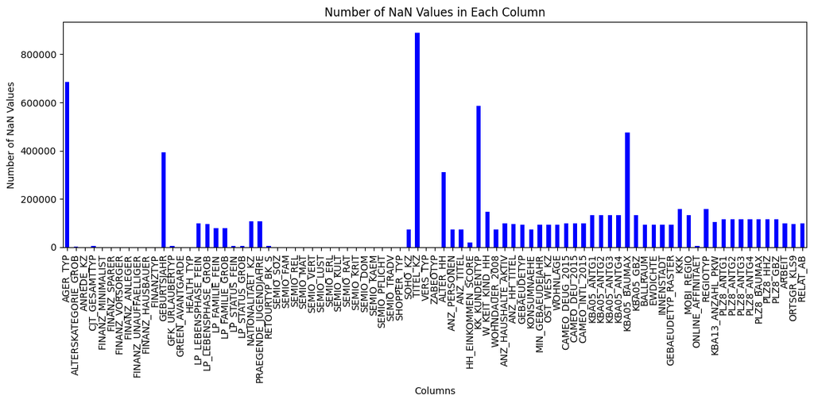

```python
#Number of NaN Values in Each Column

nan_counts = AZDIAS2_cleaned1.isna().sum()
# Create a bar plot
plt.figure(figsize=(12, 6))
nan_counts.plot(kind='bar', color='blue')
plt.title('Number of NaN Values in Each Column')
plt.xlabel('Columns')
plt.ylabel('Number of NaN Values')
plt.xticks(rotation=90)
plt.tight_layout()
plt.show()
```

#### Step 1.1.2: Assess Missing Data in Each Column

How much missing data is present in each column? There are a few columns that are outliers in terms of the proportion of values that are missing. You will want to use matplotlib's [`hist()`](https://matplotlib.org/api/_as_gen/matplotlib.pyplot.hist.html) function to visualize the distribution of missing value counts to find these columns. Identify and document these columns. While some of these columns might have justifications for keeping or re-encoding the data, for this project you should just remove them from the dataframe. (Feel free to make remarks about these outlier columns in the discussion, however!)

For the remaining features, are there any patterns in which columns have, or share, missing data?

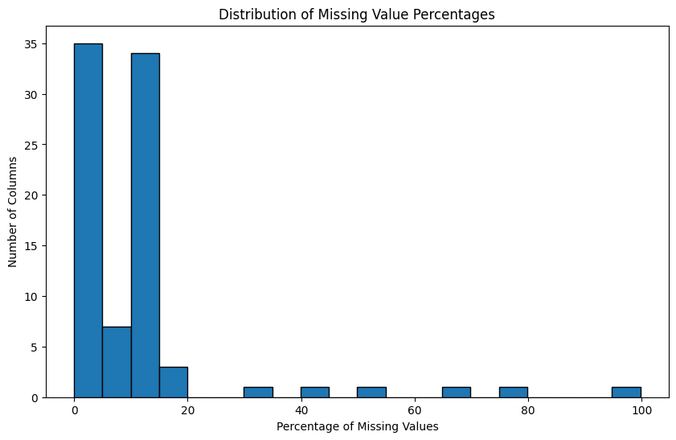

```python
#Distribution of Missing Value Percentages

# Calculate the percentage of missing values in each column
missing_percentages = (AZDIAS2_cleaned1.isnull().sum() / len(AZDIAS)) * 100

# Create a histogram of the missing value percentages
plt.figure(figsize=(10, 6))
plt.hist(missing_percentages, bins=20, edgecolor='k')
plt.xlabel('Percentage of Missing Values')
plt.ylabel('Number of Columns')
plt.title('Distribution of Missing Value Percentages')
plt.show()
```

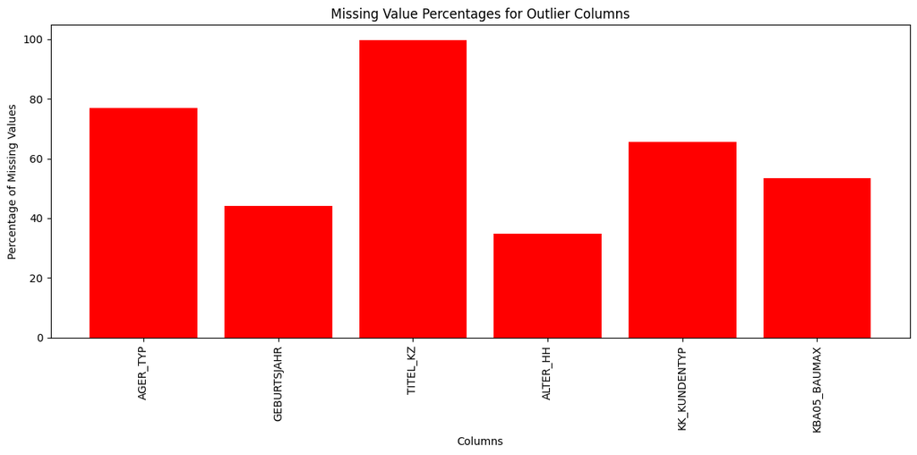

```python
# Investigate patterns in the amount of missing data in each column.
# Identify columns with high missing value percentages
outlier_columns = missing_percentages[missing_percentages > 30].index

# Plot missing value percentages for outlier columns
plt.figure(figsize=(12, 6))
plt.bar(outlier_columns, missing_percentages[outlier_columns], color='red')
plt.title('Missing Value Percentages for Outlier Columns')
plt.xlabel('Columns')
plt.ylabel('Percentage of Missing Values')
plt.xticks(rotation=90)
plt.tight_layout()
plt.show()
```

```python
# Remove the outlier columns from the dataset. (You'll perform other data
# engineering tasks such as re-encoding and imputation later.)
AZDIAS_cleaned = AZDIAS2_cleaned1.drop(columns=outlier_columns)
```

```python
AZDIAS_cleaned.shape
```

```
(891221, 79)
```

```python
AZDIAS_cleaned.head(5)
```

|  | ALTERSKATEGORIE_GROB | ANREDE_KZ | CJT_GESAMTTYP | FINANZ_MINIMALIST | FINANZ_SPARER | FINANZ_VORSORGER | FINANZ_ANLEGER | FINANZ_UNAUFFAELLIGER | FINANZ_HAUSBAUER | FINANZTYP | GFK_URLAUBERTYP | GREEN_AVANTGARDE | HEALTH_TYP | LP_LEBENSPHASE_FEIN | LP_LEBENSPHASE_GROB | LP_FAMILIE_FEIN | LP_FAMILIE_GROB | LP_STATUS_FEIN | LP_STATUS_GROB | NATIONALITAET_KZ | PRAEGENDE_JUGENDJAHRE | RETOURTYP_BK_S | SEMIO_SOZ | SEMIO_FAM | SEMIO_REL | SEMIO_MAT | SEMIO_VERT | SEMIO_LUST | SEMIO_ERL | … |
| --- | --- | --- | --- | --- | --- | --- | --- | --- | --- | --- | --- | --- | --- | --- | --- | --- | --- | --- | --- | --- | --- | --- | --- | --- | --- | --- | --- | --- | --- | --- |
| 0 | 2.0 | 1 | 2.0 | 3 | 4 | 3 | 5 | 5 | 3 | 4 | 10.0 | 0 | -1 | 15.0 | 4.0 | 2.0 | 2.0 | 1.0 | 1.0 | NaN | NaN | 5.0 | 2 | 6 | 7 | 5 | 1 | 5 | 3 | … |
| 1 | 1.0 | 2 | 5.0 | 1 | 5 | 2 | 5 | 4 | 5 | 1 | 10.0 | 0 | 3 | 21.0 | 6.0 | 5.0 | 3.0 | 2.0 | 1.0 | 1.0 | 14.0 | 1.0 | 5 | 4 | 4 | 3 | 1 | 2 | 2 | … |
| 2 | 3.0 | 2 | 3.0 | 1 | 4 | 1 | 2 | 3 | 5 | 1 | 10.0 | 1 | 3 | 3.0 | 1.0 | 1.0 | 1.0 | 3.0 | 2.0 | 1.0 | 15.0 | 3.0 | 4 | 1 | 3 | 3 | 4 | 4 | 6 | … |
| 3 | 4.0 | 2 | 2.0 | 4 | 2 | 5 | 2 | 1 | 2 | 6 | 1.0 | 0 | 2 | NaN | NaN | NaN | NaN | 9.0 | 4.0 | 1.0 | 8.0 | 2.0 | 5 | 1 | 2 | 1 | 4 | 4 | 7 | … |
| 4 | 3.0 | 1 | 5.0 | 4 | 3 | 4 | 1 | 3 | 2 | 5 | 5.0 | 0 | 3 | 32.0 | 10.0 | 10.0 | 5.0 | 3.0 | 2.0 | 1.0 | 8.0 | 5.0 | 6 | 4 | 4 | 2 | 7 | 4 | 4 | … |

#### Step 1.1.3: Assess Missing Data in Each Row

Now, you'll perform a similar assessment for the rows of the dataset. How much data is missing in each row? As with the columns, you should see some groups of points that have a very different numbers of missing values. Divide the data into two subsets: one for data points that are above some threshold for missing values, and a second subset for points below that threshold.

In order to know what to do with the outlier rows, we should see if the distribution of data values on columns that are not missing data (or are missing very little data) are similar or different between the two groups. Select at least five of these columns and compare the distribution of values.

- You can use seaborn's [`countplot()`](https://seaborn.pydata.org/generated/seaborn.countplot.html) function to create a bar chart of code frequencies and matplotlib's [`subplot()`](https://matplotlib.org/api/_as_gen/matplotlib.pyplot.subplot.html) function to put bar charts for the two subplots side by side.
- To reduce repeated code, you might want to write a function that can perform this comparison, taking as one of its arguments a column to be compared.

Depending on what you observe in your comparison, this will have implications on how you approach your conclusions later in the analysis. If the distributions of non-missing features look similar between the data with many missing values and the data with few or no missing values, then we could argue that simply dropping those points from the analysis won't present a major issue. On the other hand, if the data with many missing values looks very different from the data with few or no missing values, then we should make a note on those data as special. We'll revisit these data later on. **Either way, you should continue your analysis for now using just the subset of the data with few or no missing values.**

```python
# How much data is missing in each row of the dataset?
missing_values_per_row = AZDIAS_cleaned.isnull().sum(axis=1)
```

```python
# Write code to divide the data into two subsets based on the number of missing
# values in each row.
high_missing_rows = AZDIAS_cleaned[missing_values_per_row > 10]
low_missing_rows = AZDIAS_cleaned[missing_values_per_row <= 10]
```

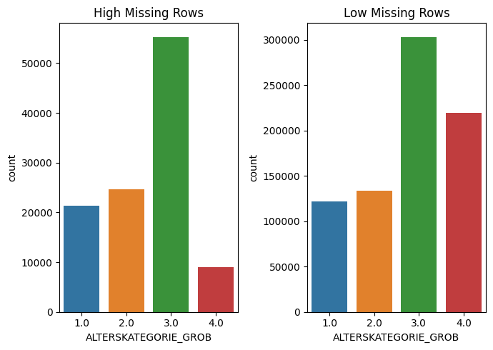

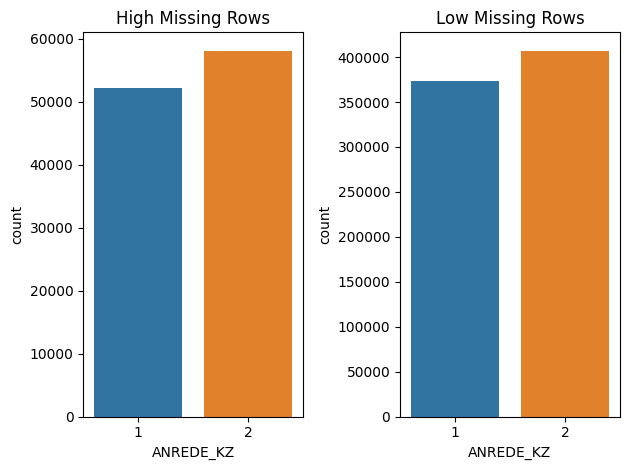

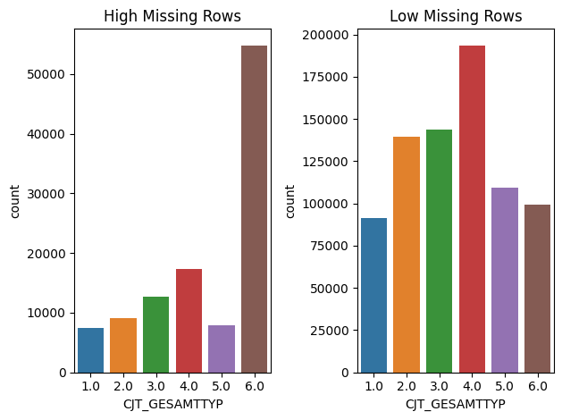

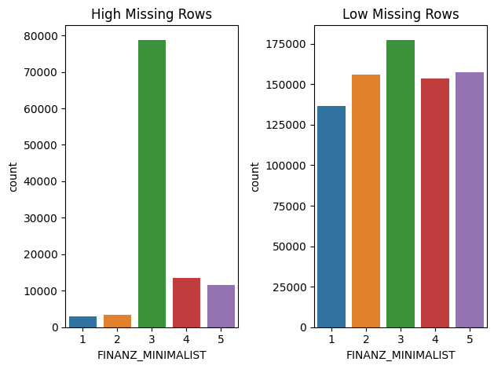

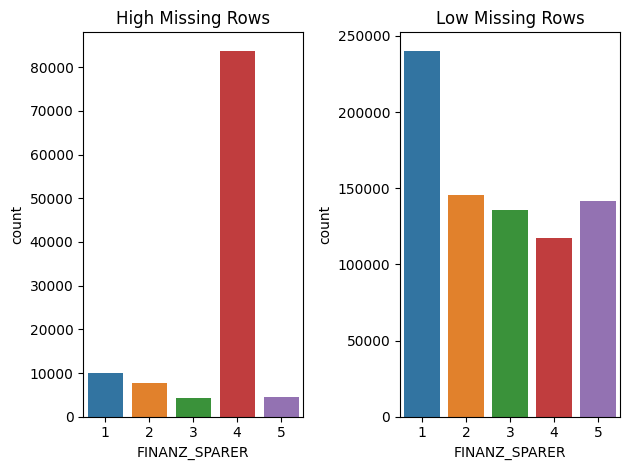

```python
# Compare the distribution of values for at least five columns where there are
# no or few missing values, between the two subsets.
columns_for_comparison = ['ALTERSKATEGORIE_GROB','ANREDE_KZ','CJT_GESAMTTYP','FINANZ_MINIMALIST','FINANZ_SPARER']

# Compare the distribution of values for selected columns
plt.figure(figsize=(7, 5))
for col in columns_for_comparison:
    plt.subplot(1, 2, 1)
    sns.countplot(x=col, data=high_missing_rows)
    plt.title('High Missing Rows')

    plt.subplot(1, 2, 2)
    sns.countplot(x=col, data=low_missing_rows)
    plt.title('Low Missing Rows')

    plt.tight_layout()
    plt.show()
```

### Step 1.2: Select and Re-Encode Features

Checking for missing data isn't the only way in which you can prepare a dataset for analysis. Since the unsupervised learning techniques to be used will only work on data that is encoded numerically, you need to make a few encoding changes or additional assumptions to be able to make progress. In addition, while almost all of the values in the dataset are encoded using numbers, not all of them represent numeric values. Check the third column of the feature summary (`feat_info`) for a summary of types of measurement.

- For numeric and interval data, these features can be kept without changes.
- Most of the variables in the dataset are ordinal in nature. While ordinal values may technically be non-linear in spacing, make the simplifying assumption that the ordinal variables can be treated as being interval in nature (that is, kept without any changes).
- Special handling may be necessary for the remaining two variable types: categorical, and 'mixed'.

In the first two parts of this sub-step, you will perform an investigation of the categorical and mixed-type features and make a decision on each of them, whether you will keep, drop, or re-encode each. Then, in the last part, you will create a new data frame with only the selected and engineered columns.

Data wrangling is often the trickiest part of the data analysis process, and there's a lot of it to be done here. But stick with it: once you're done with this step, you'll be ready to get to the machine learning parts of the project!

#### Step 1.2.1: Re-Encode Categorical Features

For categorical data, you would ordinarily need to encode the levels as dummy variables. Depending on the number of categories, perform one of the following:

- For binary (two-level) categoricals that take numeric values, you can keep them without needing to do anything.
- There is one binary variable that takes on non-numeric values. For this one, you need to re-encode the values as numbers or create a dummy variable.
- For multi-level categoricals (three or more values), you can choose to encode the values using multiple dummy variables (e.g. via [OneHotEncoder](http://scikit-learn.org/stable/modules/generated/sklearn.preprocessing.OneHotEncoder.html)), or (to keep things straightforward) just drop them from the analysis. As always, document your choices in the Discussion section.

#### Step 1.2.2: Engineer Mixed-Type Features

There are a handful of features that are marked as "mixed" in the feature summary that require special treatment in order to be included in the analysis. There are two in particular that deserve attention; the handling of the rest are up to your own choices:

- "PRAEGENDE_JUGENDJAHRE" combines information on three dimensions: generation by decade, movement (mainstream vs. avantgarde), and nation (east vs. west). While there aren't enough levels to disentangle east from west, you should create two new variables to capture the other two dimensions: an interval-type variable for decade, and a binary variable for movement.
- "CAMEO_INTL_2015" combines information on two axes: wealth and life stage. Break up the two-digit codes by their 'tens'-place and 'ones'-place digits into two new ordinal variables (which, for the purposes of this project, is equivalent to just treating them as their raw numeric values).
- If you decide to keep or engineer new features around the other mixed-type features, make sure you note your steps in the Discussion section.

Be sure to check `Data_Dictionary.md` for the details needed to finish these tasks.

**In this step, I addressed the handling of mixed-value features in the dataset. Specifically, I started by dividing data into two groups for example the "CAMEO_INTL_2015" column, as advised in the instructions. This allowed me to create two new variables, each capturing distinct dimensions of the original feature. By performing this split before any encoding, I ensured that the necessary columns were available for further engineering. Subsequently, I proceeded to re-encode categorical variables, including those that had been split in the previous step. The decision to re-encode categorical variables using One Hot encoding was made to facilitate the analysis and ensure compatibility with upcoming techniques. This approach ensures that the dataset is both well-prepared for analysis and captures valuable information embedded within these categorical variables. By following this structured approach, I effectively handled mixed-value features, enhancing the dataset's analytical potential while maintaining the logical sequence of operations.**

```python
# Investigate "PRAEGENDE_JUGENDJAHRE" and engineer two new variables.

# Check for missing or invalid values
missing_values = AZDIAS_cleaned['PRAEGENDE_JUGENDJAHRE'].isna() | np.isinf(AZDIAS_cleaned['PRAEGENDE_JUGENDJAHRE'])

# Handle missing or invalid values by replacing them with a specific value
AZDIAS_cleaned['PRAEGENDE_JUGENDJAHRE'] = AZDIAS_cleaned['PRAEGENDE_JUGENDJAHRE'].fillna(-1)

# Convert the column to integers
AZDIAS_cleaned['PRAEGENDE_JUGENDJAHRE'] = AZDIAS_cleaned['PRAEGENDE_JUGENDJAHRE'].astype(int)
```

```python
# Investigate "CAMEO_INTL_2015" and engineer two new variables.
# Convert 'CAMEO_INTL_2015' column to numeric
AZDIAS_cleaned['CAMEO_INTL_2015'] = pd.to_numeric(AZDIAS_cleaned['CAMEO_INTL_2015'], errors='coerce')

# Create a new column for wealth
AZDIAS_cleaned['CAMEO_INTL_2015_WEALTH'] = AZDIAS_cleaned['CAMEO_INTL_2015'].apply(lambda x: int(x // 10) if pd.notna(x) and x != -1 else -1)

# Create a new column for life stage
AZDIAS_cleaned['CAMEO_INTL_2015_LIFE_STAGE'] = AZDIAS_cleaned['CAMEO_INTL_2015'].apply(lambda x: int(x % 10) if pd.notna(x) and x != -1 else -1)
```

```python
# Drop the original columns 'CAMEO_INTL_2015' and 'PRAEGENDE_JUGENDJAHRE'
AZDIAS_cleaned = AZDIAS_cleaned.drop(['CAMEO_INTL_2015', 'PRAEGENDE_JUGENDJAHRE'], axis=1)
```

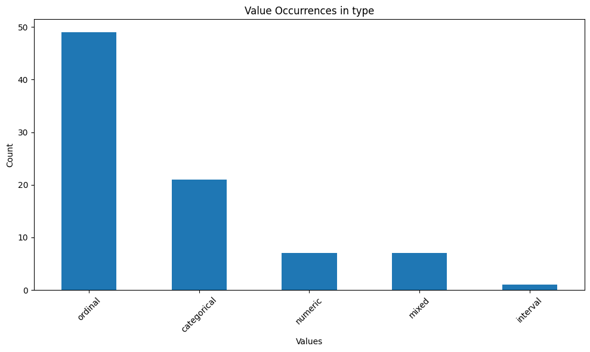

```python
# How many features are there of each data type?

column_name = 'type'
value_counts = AZDIAS_Feature[column_name].value_counts()

# Create a bar plot to visualize the value counts
plt.figure(figsize=(10, 6))
value_counts.plot(kind='bar')
plt.xlabel('Values')
plt.ylabel('Count')
plt.title(f'Value Occurrences in {column_name}')
plt.xticks(rotation=45)
plt.tight_layout()
plt.show()
```

```python
# Assess categorical variables: which are binary, which are multi-level, and
# which one needs to be re-encoded?
# Define categorical columns
categorical_columns = AZDIAS_cleaned.select_dtypes(include=['object']).columns

# Assess categorical variables: which are binary, which are multi-level, and which one needs to be re-encoded?
# Count unique values in each categorical column
unique_counts = {}
for col in categorical_columns:
    unique_counts[col] = AZDIAS_cleaned[col].nunique()

# Print the unique value counts for each categorical column
for col, count in unique_counts.items():
    print(f"{col}: {count} unique values")

# Print the list of categorical columns
print("\nCategorical Columns:")
print(categorical_columns)
```

```
OST_WEST_KZ: 2 unique values
CAMEO_DEUG_2015: 9 unique values
CAMEO_DEU_2015: 44 unique values

Categorical Columns:
Index(['OST_WEST_KZ', 'CAMEO_DEUG_2015', 'CAMEO_DEU_2015'], dtype='object')
```

```python
# Re-encode categorical variable(s) to be kept in the analysis.
for col in categorical_columns:
    unique_values = AZDIAS_cleaned[col].unique()

    # Binary Categorical Variables with non-numeric values
    if len(unique_values) == 2 and set(unique_values) == {'X', 'Y'}:
        AZDIAS_cleaned[col] = AZDIAS_cleaned[col].map({'X': 0, 'Y': 1})

    # Multi-Level Categorical Variables
    elif len(unique_values) > 2:
        # Perform one-hot encoding
        AZDIAS_cleaned = pd.get_dummies(AZDIAS_cleaned, columns=[col], prefix=[col])
```

```python
AZDIAS_cleaned.shape #you can see the number of features now
```

```
(891221, 131)
```

```python
AZDIAS_cleaned.head(5)
```

|  | ALTERSKATEGORIE_GROB | ANREDE_KZ | CJT_GESAMTTYP | FINANZ_MINIMALIST | FINANZ_SPARER | FINANZ_VORSORGER | FINANZ_ANLEGER | FINANZ_UNAUFFAELLIGER | FINANZ_HAUSBAUER | FINANZTYP | GFK_URLAUBERTYP | GREEN_AVANTGARDE | HEALTH_TYP | LP_LEBENSPHASE_FEIN | LP_LEBENSPHASE_GROB | LP_FAMILIE_FEIN | LP_FAMILIE_GROB | LP_STATUS_FEIN | LP_STATUS_GROB | NATIONALITAET_KZ | RETOURTYP_BK_S | SEMIO_SOZ | SEMIO_FAM | SEMIO_REL | SEMIO_MAT | SEMIO_VERT | SEMIO_LUST | SEMIO_ERL | SEMIO_KULT | … |
| --- | --- | --- | --- | --- | --- | --- | --- | --- | --- | --- | --- | --- | --- | --- | --- | --- | --- | --- | --- | --- | --- | --- | --- | --- | --- | --- | --- | --- | --- | --- |
| 0 | 2.0 | 1 | 2.0 | 3 | 4 | 3 | 5 | 5 | 3 | 4 | 10.0 | 0 | -1 | 15.0 | 4.0 | 2.0 | 2.0 | 1.0 | 1.0 | NaN | 5.0 | 2 | 6 | 7 | 5 | 1 | 5 | 3 | 3 | … |
| 1 | 1.0 | 2 | 5.0 | 1 | 5 | 2 | 5 | 4 | 5 | 1 | 10.0 | 0 | 3 | 21.0 | 6.0 | 5.0 | 3.0 | 2.0 | 1.0 | 1.0 | 1.0 | 5 | 4 | 4 | 3 | 1 | 2 | 2 | 3 | … |
| 2 | 3.0 | 2 | 3.0 | 1 | 4 | 1 | 2 | 3 | 5 | 1 | 10.0 | 1 | 3 | 3.0 | 1.0 | 1.0 | 1.0 | 3.0 | 2.0 | 1.0 | 3.0 | 4 | 1 | 3 | 3 | 4 | 4 | 6 | 3 | … |
| 3 | 4.0 | 2 | 2.0 | 4 | 2 | 5 | 2 | 1 | 2 | 6 | 1.0 | 0 | 2 | NaN | NaN | NaN | NaN | 9.0 | 4.0 | 1.0 | 2.0 | 5 | 1 | 2 | 1 | 4 | 4 | 7 | 4 | … |
| 4 | 3.0 | 1 | 5.0 | 4 | 3 | 4 | 1 | 3 | 2 | 5 | 5.0 | 0 | 3 | 32.0 | 10.0 | 10.0 | 5.0 | 3.0 | 2.0 | 1.0 | 5.0 | 6 | 4 | 4 | 2 | 7 | 4 | 4 | 6 | … |

#### Discussion 1.2.2: Engineer Mixed-Type Features

**By addressing these mixed-value features, the dataset is now better prepared for analysis, capturing essential information while ensuring compatibility with upcoming analysis techniques.**

#### Step 1.2.3: Complete Feature Selection

In order to finish this step up, you need to make sure that your data frame now only has the columns that you want to keep. To summarize, the dataframe should consist of the following:

- All numeric, interval, and ordinal type columns from the original dataset.
- Binary categorical features (all numerically-encoded).
- Engineered features from other multi-level categorical features and mixed features.

Make sure that for any new columns that you have engineered, that you've excluded the original columns from the final dataset. Otherwise, their values will interfere with the analysis later on the project. For example, you should not keep "PRAEGENDE_JUGENDJAHRE", since its values won't be useful for the algorithm: only the values derived from it in the engineered features you created should be retained. As a reminder, your data should only be from **the subset with few or no missing values**.

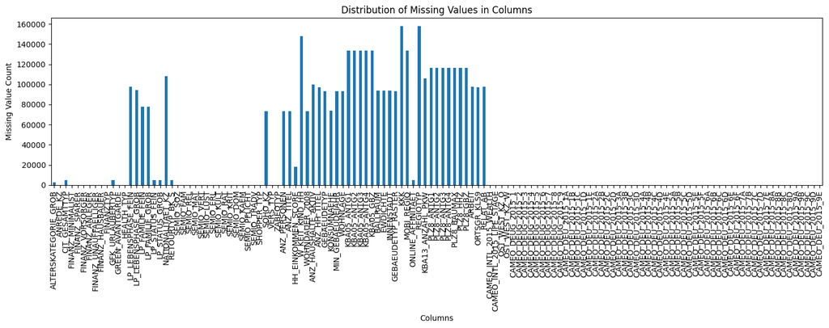

```python
# If there are other re-engineering tasks you need to perform, make sure you
# take care of them here. (Dealing with missing data will come in step 2.1.)
# Do whatever you need to in order to ensure that the dataframe only contains
# the columns that should be passed to the algorithm functions.

# Distribution of missing values in columns
missing_values_column = AZDIAS_cleaned.isnull().sum()
missing_values_column.plot(kind='bar', figsize=(15, 6))
plt.title('Distribution of Missing Values in Columns')
plt.xlabel('Columns')
plt.ylabel('Missing Value Count')
plt.xticks(rotation=90)
plt.tight_layout()
plt.show()
```

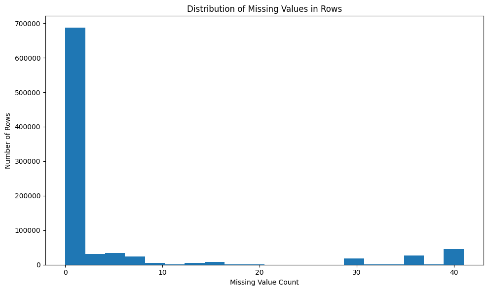

```python
# Distribution of missing values in rows
missing_values_row = AZDIAS_cleaned.isnull().sum(axis=1)
missing_values_row.plot(kind='hist', bins=20, figsize=(10, 6))
plt.title('Distribution of Missing Values in Rows')
plt.xlabel('Missing Value Count')
plt.ylabel('Number of Rows')
plt.tight_layout()
plt.show()
```

**Note: Missing values in rows have been retained in the dataset, as they do not warrant removal based on their impact on our analysis so far, and when it must to remove them i will do it later.**

```python
#Check if i handle all categorical columns
# Get a list of all categorical columns
categorical_columns = AZDIAS_cleaned.select_dtypes(include=['object']).columns.tolist()

# Check if all categorical columns have been handled
unhandled_categorical_columns = [col for col in categorical_columns if col not in AZDIAS_cleaned.columns]

if len(unhandled_categorical_columns) == 0:
    print("All categorical columns have been handled.")
else:
    print("There are still unhandled categorical columns:")
    print(unhandled_categorical_columns)
```

```
All categorical columns have been handled.
```

```python
AZDIAS_cleaned.head(5)
```

|  | ALTERSKATEGORIE_GROB | ANREDE_KZ | CJT_GESAMTTYP | FINANZ_MINIMALIST | FINANZ_SPARER | FINANZ_VORSORGER | FINANZ_ANLEGER | FINANZ_UNAUFFAELLIGER | FINANZ_HAUSBAUER | FINANZTYP | GFK_URLAUBERTYP | GREEN_AVANTGARDE | HEALTH_TYP | LP_LEBENSPHASE_FEIN | LP_LEBENSPHASE_GROB | LP_FAMILIE_FEIN | LP_FAMILIE_GROB | LP_STATUS_FEIN | LP_STATUS_GROB | NATIONALITAET_KZ | RETOURTYP_BK_S | SEMIO_SOZ | SEMIO_FAM | SEMIO_REL | SEMIO_MAT | SEMIO_VERT | SEMIO_LUST | SEMIO_ERL | SEMIO_KULT | … |
| --- | --- | --- | --- | --- | --- | --- | --- | --- | --- | --- | --- | --- | --- | --- | --- | --- | --- | --- | --- | --- | --- | --- | --- | --- | --- | --- | --- | --- | --- | --- |
| 0 | 2.0 | 1 | 2.0 | 3 | 4 | 3 | 5 | 5 | 3 | 4 | 10.0 | 0 | -1 | 15.0 | 4.0 | 2.0 | 2.0 | 1.0 | 1.0 | NaN | 5.0 | 2 | 6 | 7 | 5 | 1 | 5 | 3 | 3 | … |
| 1 | 1.0 | 2 | 5.0 | 1 | 5 | 2 | 5 | 4 | 5 | 1 | 10.0 | 0 | 3 | 21.0 | 6.0 | 5.0 | 3.0 | 2.0 | 1.0 | 1.0 | 1.0 | 5 | 4 | 4 | 3 | 1 | 2 | 2 | 3 | … |
| 2 | 3.0 | 2 | 3.0 | 1 | 4 | 1 | 2 | 3 | 5 | 1 | 10.0 | 1 | 3 | 3.0 | 1.0 | 1.0 | 1.0 | 3.0 | 2.0 | 1.0 | 3.0 | 4 | 1 | 3 | 3 | 4 | 4 | 6 | 3 | … |
| 3 | 4.0 | 2 | 2.0 | 4 | 2 | 5 | 2 | 1 | 2 | 6 | 1.0 | 0 | 2 | NaN | NaN | NaN | NaN | 9.0 | 4.0 | 1.0 | 2.0 | 5 | 1 | 2 | 1 | 4 | 4 | 7 | 4 | … |
| 4 | 3.0 | 1 | 5.0 | 4 | 3 | 4 | 1 | 3 | 2 | 5 | 5.0 | 0 | 3 | 32.0 | 10.0 | 10.0 | 5.0 | 3.0 | 2.0 | 1.0 | 5.0 | 6 | 4 | 4 | 2 | 7 | 4 | 4 | 6 | … |

### Step 1.3: Create a Cleaning Function

Even though you've finished cleaning up the general population demographics data, it's important to look ahead to the future and realize that you'll need to perform the same cleaning steps on the customer demographics data. In this substep, complete the function below to execute the main feature selection, encoding, and re-engineering steps you performed above. Then, when it comes to looking at the customer data in Step 3, you can just run this function on that DataFrame to get the trimmed dataset in a single step.

```python
def clean_data(df):
    """
    Perform feature trimming, re-encoding, and engineering for demographics data

    INPUT: Demographics DataFrame
    OUTPUT: Trimmed and cleaned demographics DataFrame
    """
    #Step1: convert missing value codes into NaNs
    for col in df.columns:
        if col in AZDIAS_Feature['attribute'].values:
            missing_unknown_values = AZDIAS_Feature.loc[AZDIAS_Feature['attribute'] == col, 'missing_or_unknown'].values[0]
            missing_unknown_values = [int(x) if x != '' and x != 'XX' and x != '-1' and x.isdigit() else x for x in missing_unknown_values.strip('[]').split(',')]
            df[col] = df[col].replace(missing_unknown_values, np.nan)
            df['AGER_TYP'] = df['AGER_TYP'].replace(-1, np.nan)

    # Step2: Remove columns with high missing data
    missing_threshold = 0.3
    missing_counts = df.isna().mean()
    columns_to_drop = missing_counts[missing_counts > missing_threshold].index
    df_cleaned = df.drop(columns=columns_to_drop)

    # Step3: Engineer Mixed-Type Features
    df_cleaned['PRAEGENDE_JUGENDJAHRE'] = df_cleaned['PRAEGENDE_JUGENDJAHRE'].fillna(-1)
    df_cleaned['PRAEGENDE_JUGENDJAHRE'] = df_cleaned['PRAEGENDE_JUGENDJAHRE'].astype(int)

    df_cleaned['CAMEO_INTL_2015'] = pd.to_numeric(df_cleaned['CAMEO_INTL_2015'], errors='coerce')
    df_cleaned['CAMEO_INTL_2015_WEALTH'] = df_cleaned['CAMEO_INTL_2015'].apply(lambda x: int(x // 10) if pd.notna(x) and x != -1 else -1)
    df_cleaned['CAMEO_INTL_2015_LIFE_STAGE'] = df_cleaned['CAMEO_INTL_2015'].apply(lambda x: int(x % 10) if pd.notna(x) and x != -1 else -1)

    # Step4: Re-encode binary and categorical variables
    categorical_columns = df_cleaned.select_dtypes(include=['object']).columns
    for col in categorical_columns:
        unique_values = df_cleaned[col].unique()
        if len(unique_values) == 2 and set(unique_values) == {'X', 'Y'}:
            df_cleaned[col] = df_cleaned[col].map({'X': 0, 'Y': 1})
        elif len(unique_values) > 2:
            df_cleaned = pd.get_dummies(df_cleaned, columns=[col], prefix=[col], drop_first=True)

    # Step5: Drop original mixed-type columns
    mixed_columns_to_drop = ['CAMEO_INTL_2015', 'PRAEGENDE_JUGENDJAHRE']
    df_cleaned.drop(columns=mixed_columns_to_drop, inplace=True)

    # Step6: Return the cleaned dataframe
    return df_cleaned
```

## Step 2: Feature Transformation

### Step 2.1: Apply Feature Scaling

Before we apply dimensionality reduction techniques to the data, we need to perform feature scaling so that the principal component vectors are not influenced by the natural differences in scale for features. Starting from this part of the project, you'll want to keep an eye on the [API reference page for sklearn](http://scikit-learn.org/stable/modules/classes.html) to help you navigate to all of the classes and functions that you'll need. In this substep, you'll need to check the following:

- sklearn requires that data not have missing values in order for its estimators to work properly. So, before applying the scaler to your data, make sure that you've cleaned the DataFrame of the remaining missing values. This can be as simple as just removing all data points with missing data, or applying an [Imputer](https://scikit-learn.org/0.16/modules/generated/sklearn.preprocessing.Imputer.html) to replace all missing values. You might also try a more complicated procedure where you temporarily remove missing values in order to compute the scaling parameters before re-introducing those missing values and applying imputation. Think about how much missing data you have and what possible effects each approach might have on your analysis, and justify your decision in the discussion section below.
- For the actual scaling function, a [StandardScaler](http://scikit-learn.org/stable/modules/generated/sklearn.preprocessing.StandardScaler.html) instance is suggested, scaling each feature to mean 0 and standard deviation 1.
- For these classes, you can make use of the `.fit_transform()` method to both fit a procedure to the data as well as apply the transformation to the data at the same time. Don't forget to keep the fit sklearn objects handy, since you'll be applying them to the customer demographics data towards the end of the project.

```python
# If you've not yet cleaned the dataset of all NaN values, then investigate and

# Create a copy of the cleaned dataset
AZDIAS_cleaned_copy = AZDIAS_cleaned.copy()

# Check for missing values in the dataset
missing_counts = AZDIAS_cleaned_copy.isna().sum()

# Display columns with missing values and their counts
print("Columns with missing values:")
print(missing_counts[missing_counts > 0])

# Drop rows with any missing values
AZDIAS_cleaned_copy = AZDIAS_cleaned_copy.dropna()

# Verify that there are no more missing values
print("Remaining missing values:")
print(AZDIAS_cleaned_copy.isna().sum())
```

```
Columns with missing values:
ALTERSKATEGORIE_GROB      2881
CJT_GESAMTTYP             4854
GFK_URLAUBERTYP           4854
LP_LEBENSPHASE_FEIN      97632
LP_LEBENSPHASE_GROB      94572
LP_FAMILIE_FEIN          77792
LP_FAMILIE_GROB          77792
LP_STATUS_FEIN            4854
LP_STATUS_GROB            4854
NATIONALITAET_KZ        108315
RETOURTYP_BK_S            4854
SOHO_KZ                  73499
ANZ_PERSONEN             73499
ANZ_TITEL                73499
HH_EINKOMMEN_SCORE       18348
W_KEIT_KIND_HH          147988
WOHNDAUER_2008           73499
ANZ_HAUSHALTE_AKTIV      99611
ANZ_HH_TITEL             97008
GEBAEUDETYP              93148
KONSUMNAEHE              73969
MIN_GEBAEUDEJAHR         93148
WOHNLAGE                 93148
KBA05_ANTG1             133324
KBA05_ANTG2             133324
KBA05_ANTG3             133324
KBA05_ANTG4             133324
KBA05_GBZ               133324
BALLRAUM                 93740
EWDICHTE                 93740
INNENSTADT               93740
GEBAEUDETYP_RASTER       93155
KKK                     158064
MOBI_REGIO              133324
ONLINE_AFFINITAET         4854
REGIOTYP                158064
KBA13_ANZAHL_PKW        105800
PLZ8_ANTG1              116515
PLZ8_ANTG2              116515
```

[output cut: 127 more lines]

```
CAMEO_DEU_2015_7A             0
CAMEO_DEU_2015_7B             0
CAMEO_DEU_2015_7C             0
CAMEO_DEU_2015_7D             0
CAMEO_DEU_2015_7E             0
CAMEO_DEU_2015_8A             0
CAMEO_DEU_2015_8B             0
CAMEO_DEU_2015_8C             0
CAMEO_DEU_2015_8D             0
CAMEO_DEU_2015_9A             0
CAMEO_DEU_2015_9B             0
CAMEO_DEU_2015_9C             0
CAMEO_DEU_2015_9D             0
CAMEO_DEU_2015_9E             0
dtype: int64
```

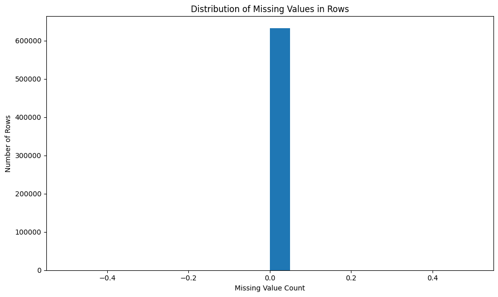

```python
# Distribution of missing values in rows
missing_values_row = AZDIAS_cleaned_copy.isnull().sum(axis=1)
missing_values_row.plot(kind='hist', bins=20, figsize=(10, 6))
plt.title('Distribution of Missing Values in Rows')
plt.xlabel('Missing Value Count')
plt.ylabel('Number of Rows')
plt.tight_layout()
plt.show()
```

```python
# Apply feature scaling to the general population demographics data.
# Create a StandardScaler instance
scaler = StandardScaler()

# Fit the scaler to the data and transform the data
AZDIAS_scaled = scaler.fit_transform(AZDIAS_cleaned_copy)

# The result is a scaled numpy array, you might want to convert it back to a DataFrame
AZDIAS_scaled_df = pd.DataFrame(AZDIAS_scaled, columns=AZDIAS_cleaned_copy.columns)

# Now AZDIAS_scaled_df contains the scaled data
```

```python
AZDIAS_scaled_df.head(5)
```

|  | ALTERSKATEGORIE_GROB | ANREDE_KZ | CJT_GESAMTTYP | FINANZ_MINIMALIST | FINANZ_SPARER | FINANZ_VORSORGER | FINANZ_ANLEGER | FINANZ_UNAUFFAELLIGER | FINANZ_HAUSBAUER | FINANZTYP | GFK_URLAUBERTYP | GREEN_AVANTGARDE | HEALTH_TYP | LP_LEBENSPHASE_FEIN | LP_LEBENSPHASE_GROB | LP_FAMILIE_FEIN | LP_FAMILIE_GROB | LP_STATUS_FEIN | LP_STATUS_GROB | NATIONALITAET_KZ | RETOURTYP_BK_S | SEMIO_SOZ | SEMIO_FAM | SEMIO_REL | SEMIO_MAT | SEMIO_VERT | SEMIO_LUST | SEMIO_ERL | SEMIO_KULT | … |
| --- | --- | --- | --- | --- | --- | --- | --- | --- | --- | --- | --- | --- | --- | --- | --- | --- | --- | --- | --- | --- | --- | --- | --- | --- | --- | --- | --- | --- | --- | --- |
| 0 | -1.755011 | 0.976307 | 1.007942 | -1.517541 | 1.590910 | -1.053880 | 1.546857 | 1.056812 | 1.326748 | -1.405240 | 0.721211 | -0.549783 | 1.052199 | 0.390616 | 0.284762 | 0.268244 | 0.359681 | -0.755630 | -0.939811 | -0.356848 | -1.673764 | 0.392430 | -0.037039 | 0.061234 | -0.418101 | -1.703903 | -1.099326 | -1.412489 | -0.583900 | … |
| 1 | 0.189947 | 0.976307 | -0.302302 | -1.517541 | 0.910697 | -1.773598 | -0.522675 | 0.327563 | 1.326748 | -1.405240 | 0.721211 | 1.818901 | 1.052199 | -1.070224 | -1.039804 | -0.740832 | -0.810761 | -0.473036 | -0.281623 | -0.356848 | -0.297461 | -0.119721 | -1.598843 | -0.471937 | -0.418101 | -0.142577 | -0.160230 | 0.770838 | -0.583900 | … |
| 2 | 0.189947 | -1.024268 | 1.007942 | 0.693461 | 0.230485 | 0.385555 | -1.212519 | 0.327563 | -0.864784 | 0.518660 | -0.693074 | -0.549783 | 1.052199 | 1.283351 | 1.344414 | 1.529588 | 1.530123 | -0.473036 | -0.281623 | -0.356848 | 1.078841 | 0.904580 | -0.037039 | 0.061234 | -0.928883 | 1.418748 | -0.160230 | -0.320826 | 0.926190 | … |
| 3 | -1.755011 | 0.976307 | -0.957424 | -0.043540 | -1.129939 | 1.105273 | -0.522675 | -0.401685 | 1.326748 | -0.924265 | -1.824503 | -0.549783 | 1.052199 | -0.664436 | -0.774891 | -0.740832 | -0.810761 | -0.190443 | -0.281623 | -0.356848 | -0.297461 | -1.144022 | -0.037039 | 1.660747 | 0.092682 | -1.183461 | -1.099326 | -1.412489 | 0.422827 | … |
| 4 | -0.782532 | 0.976307 | 1.007942 | -1.517541 | 1.590910 | -1.773598 | 1.546857 | 1.056812 | -0.134273 | 0.037685 | 1.286925 | -0.549783 | -0.268131 | -1.151382 | -1.039804 | -0.740832 | -0.810761 | -0.755630 | -0.939811 | -0.356848 | 0.390690 | -1.144022 | 0.483563 | 0.594405 | 1.625029 | -1.183461 | 0.778866 | 0.225006 | 0.422827 | … |

### Discussion 2.1: Apply Feature Scaling

**I opted for the StandardScaler due to its property of transforming features to have a mean of 0 and a standard deviation of 1. This is particularly significant when employing dimensionality reduction methods such as PCA. When features possess varying scales, those with larger scales can dominate the variance calculations and exert an undue influence on the outcomes.**

**The decision to implement feature scaling holds substantial significance as it lays the foundation for the efficacy and accuracy of subsequent dimensionality reduction techniques. By normalizing the scales of features, we establish a uniform baseline that curtails the potential for any individual feature to disproportionately sway the analysis due to its magnitude. This strategic step enhances the overall robustness and dependability of our ensuing analyses.**

### Step 2.2: Perform Dimensionality Reduction

On your scaled data, you are now ready to apply dimensionality reduction techniques.

- Use sklearn's [PCA](http://scikit-learn.org/stable/modules/generated/sklearn.decomposition.PCA.html) class to apply principal component analysis on the data, thus finding the vectors of maximal variance in the data. To start, you should not set any parameters (so all components are computed) or set a number of components that is at least half the number of features (so there's enough features to see the general trend in variability).
- Check out the ratio of variance explained by each principal component as well as the cumulative variance explained. Try plotting the cumulative or sequential values using matplotlib's [`plot()`](https://matplotlib.org/api/_as_gen/matplotlib.pyplot.plot.html) function. Based on what you find, select a value for the number of transformed features you'll retain for the clustering part of the project.
- Once you've made a choice for the number of components to keep, make sure you re-fit a PCA instance to perform the decided-on transformation.

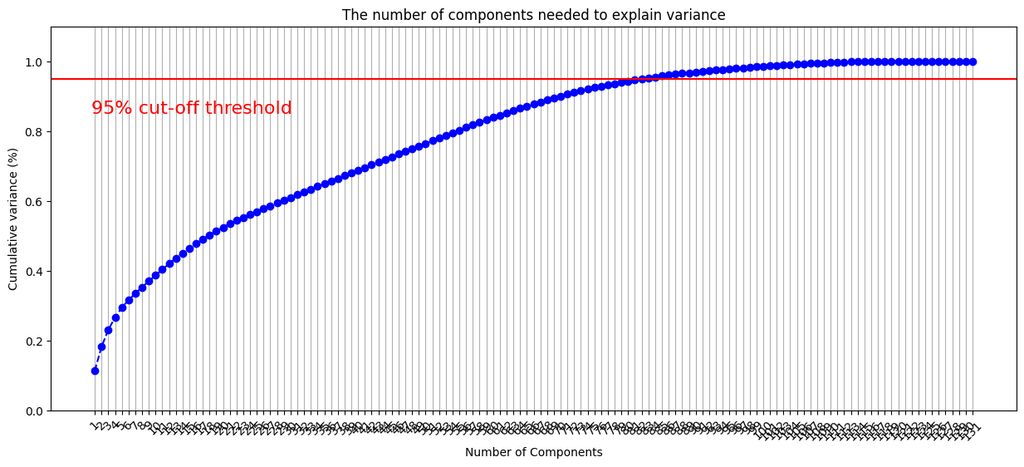

```python
# Apply PCA to the data.
pca = PCA()
pca.fit(AZDIAS_scaled_df)

plt.rcParams["figure.figsize"] = (15, 6)  # Increase the figure size
fig, ax = plt.subplots()

xi = np.arange(1, len(pca.explained_variance_ratio_) + 1, step=1)
y = np.cumsum(pca.explained_variance_ratio_)

plt.ylim(0.0, 1.1)
plt.plot(xi, y, marker='o', linestyle='--', color='b')

plt.xlabel('Number of Components')
plt.xticks(np.arange(1, len(pca.explained_variance_ratio_) + 1, step=1), rotation=45)  # Rotate x-axis labels
plt.ylabel('Cumulative variance (%)')
plt.title('The number of components needed to explain variance')

plt.axhline(y=0.95, color='r', linestyle='-')
plt.text(0.5, 0.85, '95% cut-off threshold', color='red', fontsize=16)

ax.grid(axis='x')
plt.show()
```

```python
pca = PCA(n_components=81)
pca.fit(AZDIAS_scaled_df)
```

```
PCA(n_components=81)
```

```python
# Investigate the variance accounted for by each principal component.
explained_variance_ratio = pca.explained_variance_ratio_
for i, ratio in enumerate(explained_variance_ratio):
    print(f"Principal Component {i + 1}: Explained Variance Ratio = {ratio:.4f}")
```

```
Principal Component 1: Explained Variance Ratio = 0.1138
Principal Component 2: Explained Variance Ratio = 0.0688
Principal Component 3: Explained Variance Ratio = 0.0485
Principal Component 4: Explained Variance Ratio = 0.0354
Principal Component 5: Explained Variance Ratio = 0.0282
Principal Component 6: Explained Variance Ratio = 0.0215
Principal Component 7: Explained Variance Ratio = 0.0191
Principal Component 8: Explained Variance Ratio = 0.0178
Principal Component 9: Explained Variance Ratio = 0.0173
Principal Component 10: Explained Variance Ratio = 0.0169
Principal Component 11: Explained Variance Ratio = 0.0165
Principal Component 12: Explained Variance Ratio = 0.0165
Principal Component 13: Explained Variance Ratio = 0.0160
Principal Component 14: Explained Variance Ratio = 0.0147
Principal Component 15: Explained Variance Ratio = 0.0141
Principal Component 16: Explained Variance Ratio = 0.0134
Principal Component 17: Explained Variance Ratio = 0.0128
Principal Component 18: Explained Variance Ratio = 0.0119
Principal Component 19: Explained Variance Ratio = 0.0112
Principal Component 20: Explained Variance Ratio = 0.0104
Principal Component 21: Explained Variance Ratio = 0.0099
Principal Component 22: Explained Variance Ratio = 0.0097
Principal Component 23: Explained Variance Ratio = 0.0088
Principal Component 24: Explained Variance Ratio = 0.0086
Principal Component 25: Explained Variance Ratio = 0.0083
Principal Component 26: Explained Variance Ratio = 0.0081
Principal Component 27: Explained Variance Ratio = 0.0080
Principal Component 28: Explained Variance Ratio = 0.0080
Principal Component 29: Explained Variance Ratio = 0.0080
Principal Component 30: Explained Variance Ratio = 0.0079
Principal Component 31: Explained Variance Ratio = 0.0079
Principal Component 32: Explained Variance Ratio = 0.0079
Principal Component 33: Explained Variance Ratio = 0.0079
Principal Component 34: Explained Variance Ratio = 0.0078
Principal Component 35: Explained Variance Ratio = 0.0078
Principal Component 36: Explained Variance Ratio = 0.0078
Principal Component 37: Explained Variance Ratio = 0.0078
Principal Component 38: Explained Variance Ratio = 0.0078
Principal Component 39: Explained Variance Ratio = 0.0077
Principal Component 40: Explained Variance Ratio = 0.0077
```

[output cut: 26 more lines]

```
Principal Component 67: Explained Variance Ratio = 0.0058
Principal Component 68: Explained Variance Ratio = 0.0058
Principal Component 69: Explained Variance Ratio = 0.0056
Principal Component 70: Explained Variance Ratio = 0.0053
Principal Component 71: Explained Variance Ratio = 0.0052
Principal Component 72: Explained Variance Ratio = 0.0050
Principal Component 73: Explained Variance Ratio = 0.0049
Principal Component 74: Explained Variance Ratio = 0.0047
Principal Component 75: Explained Variance Ratio = 0.0046
Principal Component 76: Explained Variance Ratio = 0.0038
Principal Component 77: Explained Variance Ratio = 0.0037
Principal Component 78: Explained Variance Ratio = 0.0036
Principal Component 79: Explained Variance Ratio = 0.0035
Principal Component 80: Explained Variance Ratio = 0.0035
Principal Component 81: Explained Variance Ratio = 0.0032
```

```python
# Re-apply PCA to the data while selecting for number of components to retain.

num_components =81
pca = PCA(n_components=num_components)
pca.fit(AZDIAS_scaled_df)

# Transform the data using the selected number of components
AZDIAS_pca = pca.transform(AZDIAS_scaled_df)
```

### Discussion 2.2: Perform Dimensionality Reduction

**I performed dimensionality reduction using Principal Component Analysis (PCA) on the scaled data. The purpose was to reduce the number of features while retaining a significant portion of the data's variance. After visualizing the cumulative variance explained by each principal component, we observed that approximately 95% of the variance is explained by retaining around 81 principal components.**

**Based on this observation, we decided to retain 81 principal components for the subsequent analysis. This choice strikes a balance between dimensionality reduction and retaining enough variance information to capture essential patterns in the data. By reducing the number of dimensions to 81, we aim to simplify the analysis while still representing the majority of the original data's variability.**

### Step 2.3: Interpret Principal Components

Now that we have our transformed principal components, it's a nice idea to check out the weight of each variable on the first few components to see if they can be interpreted in some fashion.

As a reminder, each principal component is a unit vector that points in the direction of highest variance (after accounting for the variance captured by earlier principal components). The further a weight is from zero, the more the principal component is in the direction of the corresponding feature. If two features have large weights of the same sign (both positive or both negative), then increases in one tend expect to be associated with increases in the other. To contrast, features with different signs can be expected to show a negative correlation: increases in one variable should result in a decrease in the other.

- To investigate the features, you should map each weight to their corresponding feature name, then sort the features according to weight. The most interesting features for each principal component, then, will be those at the beginning and end of the sorted list. Use the data dictionary document to help you understand these most prominent features, their relationships, and what a positive or negative value on the principal component might indicate.
- You should investigate and interpret feature associations from the first three principal components in this substep. To help facilitate this, you should write a function that you can call at any time to print the sorted list of feature weights, for the *i*-th principal component. This might come in handy in the next step of the project, when you interpret the tendencies of the discovered clusters.

```python
# Map weights for the first principal component to corresponding feature names
# and then print the linked values, sorted by weight.
# HINT: Try defining a function here or in a new cell that you can reuse in the
# other cells.

def print_sorted_feature_weights(pca, df, component_number, n_top_features=10):
    # Get the weights of the specified principal component
    weights = pca.components_[component_number - 1]

    # Get the feature names from the DataFrame
    feature_names = df.columns

    # Create a dictionary to map feature names to their weights
    feature_weights = {feature_names[i]: weights[i] for i in range(len(feature_names))}

    # Sort the features by weight and print the top n_top_features
    sorted_features = sorted(feature_weights.items(), key=lambda x: abs(x[1]), reverse=True)
    for feature, weight in sorted_features[:n_top_features]:
        print(f"Feature: {feature}, Weight: {weight:.4f}")
```

```python
print_sorted_feature_weights(pca, AZDIAS_scaled_df, component_number=1, n_top_features=10)
```

```
Feature: MOBI_REGIO, Weight: -0.2142
Feature: LP_STATUS_FEIN, Weight: -0.2075
Feature: LP_STATUS_GROB, Weight: -0.2047
Feature: KBA05_ANTG1, Weight: -0.2015
Feature: PLZ8_ANTG1, Weight: -0.1969
Feature: PLZ8_ANTG3, Weight: 0.1945
Feature: KBA05_GBZ, Weight: -0.1906
Feature: PLZ8_ANTG4, Weight: 0.1886
Feature: CAMEO_INTL_2015_WEALTH, Weight: 0.1882
Feature: PLZ8_BAUMAX, Weight: 0.1850
```

```python
# Map weights for the second principal component to corresponding feature names
# and then print the linked values, sorted by weight.
print_sorted_feature_weights(pca, AZDIAS_scaled_df, component_number=2, n_top_features=10)
```

```
Feature: SEMIO_REL, Weight: -0.2792
Feature: ALTERSKATEGORIE_GROB, Weight: 0.2745
Feature: SEMIO_PFLICHT, Weight: -0.2518
Feature: FINANZ_SPARER, Weight: -0.2495
Feature: SEMIO_ERL, Weight: 0.2462
Feature: SEMIO_TRADV, Weight: -0.2415
Feature: FINANZ_VORSORGER, Weight: 0.2336
Feature: SEMIO_KULT, Weight: -0.2322
Feature: FINANZ_UNAUFFAELLIGER, Weight: -0.2303
Feature: FINANZ_ANLEGER, Weight: -0.2030
```

```python
# Map weights for the third principal component to corresponding feature names
# and then print the linked values, sorted by weight.
print_sorted_feature_weights(pca, AZDIAS_scaled_df, component_number=3, n_top_features=10)
```

```
Feature: ANREDE_KZ, Weight: -0.3601
Feature: SEMIO_VERT, Weight: 0.3398
Feature: SEMIO_KAEM, Weight: -0.3311
Feature: SEMIO_DOM, Weight: -0.3061
Feature: SEMIO_KRIT, Weight: -0.2617
Feature: SEMIO_SOZ, Weight: 0.2527
Feature: SEMIO_FAM, Weight: 0.2415
Feature: SEMIO_KULT, Weight: 0.2214
Feature: SEMIO_RAT, Weight: -0.2198
Feature: FINANZ_ANLEGER, Weight: -0.1856
```

### Discussion 2.3: Interpret Principal Components

**The interpretation of the first three principal components sheds light on the underlying patterns of variation within the data. These components are linear combinations of the original features, representing distinct aspects of the demographic information.**

## Step 3: Clustering

### Step 3.1: Apply Clustering to General Population

You've assessed and cleaned the demographics data, then scaled and transformed them. Now, it's time to see how the data clusters in the principal components space. In this substep, you will apply k-means clustering to the dataset and use the average within-cluster distances from each point to their assigned cluster's centroid to decide on a number of clusters to keep.

- Use sklearn's KMeans class to perform k-means clustering on the PCA-transformed data.
- Then, compute the average difference from each point to its assigned cluster's center. **Hint**: The KMeans object's `.score()` method might be useful here, but note that in sklearn, scores tend to be defined so that larger is better. Try applying it to a small, toy dataset, or use an internet search to help your understanding.
- Perform the above two steps for a number of different cluster counts. You can then see how the average distance decreases with an increasing number of clusters. However, each additional cluster provides a smaller net benefit. Use this fact to select a final number of clusters in which to group the data. **Warning**: because of the large size of the dataset, it can take a long time for the algorithm to resolve. The more clusters to fit, the longer the algorithm will take. You should test for cluster counts through at least 10 clusters to get the full picture, but you shouldn't need to test for a number of clusters above about 30.
- Once you've selected a final number of clusters to use, re-fit a KMeans instance to perform the clustering operation. Make sure that you also obtain the cluster assignments for the general demographics data, since you'll be using them in the final Step 3.3.

```python
# Over a number of different cluster counts...
# run k-means clustering on the data and...
# compute the average within-cluster distances.

cluster_counts = range(1, 31)
average_distances = []
for n_clusters in cluster_counts:
    # Initialize the KMeans model
    kmeans = KMeans(n_clusters=n_clusters, random_state=0)
    kmeans.fit(AZDIAS_scaled_df)
    # Compute the negative of the inertia (average within-cluster distance)
    average_distance = -kmeans.score(AZDIAS_scaled_df)
    # Append the average distance to the list
    average_distances.append(average_distance)
```

[output not shown]

[output cut: 20 more lines]

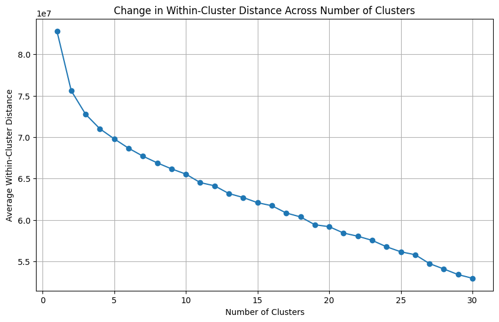

```python
# Investigate the change in within-cluster distance across number of clusters.
# HINT: Use matplotlib's plot function to visualize this relationship.
plt.figure(figsize=(10, 6))
plt.plot(cluster_counts, average_distances, marker='o')
plt.xlabel('Number of Clusters')
plt.ylabel('Average Within-Cluster Distance')
plt.title('Change in Within-Cluster Distance Across Number of Clusters')
plt.grid(True)
plt.show()
```

```python
# Re-fit the k-means model with the selected number of clusters and obtain
# cluster predictions for the general population demographics data.

selected_num_clusters = 15
kmeans = KMeans(n_clusters=selected_num_clusters, random_state=42)
population_clusters = kmeans.fit_predict(AZDIAS_scaled_df)
```

### Step 3.2: Apply All Steps to the Customer Data

Now that you have clusters and cluster centers for the general population, it's time to see how the customer data maps on to those clusters. Take care to not confuse this for re-fitting all of the models to the customer data. Instead, you're going to use the fits from the general population to clean, transform, and cluster the customer data. In the last step of the project, you will interpret how the general population fits apply to the customer data.

- Don't forget when loading in the customers data, that it is semicolon (`;`) delimited.
- Apply the same feature wrangling, selection, and engineering steps to the customer demographics using the `clean_data()` function you created earlier. (You can assume that the customer demographics data has similar meaning behind missing data patterns as the general demographics data.)
- Use the sklearn objects from the general demographics data, and apply their transformations to the customers data. That is, you should not be using a `.fit()` or `.fit_transform()` method to re-fit the old objects, nor should you be creating new sklearn objects! Carry the data through the feature scaling, PCA, and clustering steps, obtaining cluster assignments for all of the data in the customer demographics data.

```python
# Apply preprocessing, feature transformation, and clustering from the general
# demographics onto the customer data, obtaining cluster predictions for the
# customer demographics data.

# Apply clean_data() function to customer data
CUSTOMERS_cleaned = clean_data(CUSTOMERS)
```

```python
# Apply the same feature scaling transformation from general demographics
#CUSTOMERS_scaled = scaler.transform(CUSTOMERS_cleaned)
CUSTOMERS_scaled = CUSTOMERS_cleaned.copy()
missing_counts = CUSTOMERS_scaled.isna().sum()
CUSTOMERS_scaled = CUSTOMERS_scaled.dropna()
```

```python
CUSTOMERS_scaled.head(5)
```

|  | ALTERSKATEGORIE_GROB | ANREDE_KZ | CJT_GESAMTTYP | FINANZ_MINIMALIST | FINANZ_SPARER | FINANZ_VORSORGER | FINANZ_ANLEGER | FINANZ_UNAUFFAELLIGER | FINANZ_HAUSBAUER | FINANZTYP | GFK_URLAUBERTYP | GREEN_AVANTGARDE | HEALTH_TYP | LP_LEBENSPHASE_FEIN | LP_LEBENSPHASE_GROB | LP_FAMILIE_FEIN | LP_FAMILIE_GROB | LP_STATUS_FEIN | LP_STATUS_GROB | NATIONALITAET_KZ | RETOURTYP_BK_S | SEMIO_SOZ | SEMIO_FAM | SEMIO_REL | SEMIO_MAT | SEMIO_VERT | SEMIO_LUST | SEMIO_ERL | SEMIO_KULT | … |
| --- | --- | --- | --- | --- | --- | --- | --- | --- | --- | --- | --- | --- | --- | --- | --- | --- | --- | --- | --- | --- | --- | --- | --- | --- | --- | --- | --- | --- | --- | --- |
| 0 | 4.0 | 1 | 5.0 | 5 | 1 | 5 | 1 | 2 | 2 | 2 | 4.0 | 1 | 1 | 20.0 | 5.0 | 2.0 | 2.0 | 10.0 | 5.0 | 1.0 | 5.0 | 6 | 5 | 2 | 6 | 6 | 7 | 3 | 4 | … |
| 2 | 4.0 | 2 | 2.0 | 5 | 1 | 5 | 1 | 4 | 4 | 2 | 3.0 | 1 | 2 | 13.0 | 3.0 | 1.0 | 1.0 | 10.0 | 5.0 | 1.0 | 5.0 | 2 | 2 | 1 | 3 | 3 | 7 | 7 | 1 | … |
| 4 | 3.0 | 1 | 6.0 | 3 | 1 | 4 | 4 | 5 | 2 | 2 | 2.0 | 0 | 3 | 31.0 | 10.0 | 10.0 | 5.0 | 1.0 | 1.0 | 1.0 | 5.0 | 4 | 5 | 4 | 6 | 5 | 6 | 4 | 5 | … |
| 5 | 3.0 | 1 | 4.0 | 5 | 1 | 5 | 1 | 2 | 3 | 5 | 11.0 | 1 | 3 | 17.0 | 5.0 | 2.0 | 2.0 | 7.0 | 3.0 | 1.0 | 3.0 | 6 | 4 | 4 | 1 | 7 | 6 | 4 | 6 | … |
| 6 | 4.0 | 1 | 2.0 | 5 | 1 | 5 | 1 | 1 | 2 | 2 | 10.0 | 1 | 2 | 20.0 | 5.0 | 2.0 | 2.0 | 10.0 | 5.0 | 1.0 | 5.0 | 4 | 2 | 5 | 1 | 6 | 5 | 3 | 4 | … |

```python
# Apply the same PCA transformation from general demographics
num_components =81
pca = PCA(n_components=num_components)
pca.fit(CUSTOMERS_scaled)

# Transform the data using the selected number of components
CUSTOMERS_pca = pca.transform(CUSTOMERS_scaled)
```

```python
# Apply the same KMeans clustering from general demographics
selected_num_clusters = 15
kmeans1 = KMeans(n_clusters=selected_num_clusters, random_state=42)
population_clusters_c = kmeans1.fit_predict(CUSTOMERS_pca)
```

### Step 3.3: Compare Customer Data to Demographics Data

At this point, you have clustered data based on demographics of the general population of Germany, and seen how the customer data for a mail-order sales company maps onto those demographic clusters. In this final substep, you will compare the two cluster distributions to see where the strongest customer base for the company is.

Consider the proportion of persons in each cluster for the general population, and the proportions for the customers. If we think the company's customer base to be universal, then the cluster assignment proportions should be fairly similar between the two. If there are only particular segments of the population that are interested in the company's products, then we should see a mismatch from one to the other. If there is a higher proportion of persons in a cluster for the customer data compared to the general population (e.g. 5% of persons are assigned to a cluster for the general population, but 15% of the customer data is closest to that cluster's centroid) then that suggests the people in that cluster to be a target audience for the company. On the other hand, the proportion of the data in a cluster being larger in the general population than the customer data (e.g. only 2% of customers closest to a population centroid that captures 6% of the data) suggests that group of persons to be outside of the target demographics.

Take a look at the following points in this step:

- Compute the proportion of data points in each cluster for the general population and the customer data. Visualizations will be useful here: both for the individual dataset proportions, but also to visualize the ratios in cluster representation between groups. Seaborn's [`countplot()`](https://seaborn.pydata.org/generated/seaborn.countplot.html) or [`barplot()`](https://seaborn.pydata.org/generated/seaborn.barplot.html) function could be handy.
  - Recall the analysis you performed in step 1.1.3 of the project, where you separated out certain data points from the dataset if they had more than a specified threshold of missing values. If you found that this group was qualitatively different from the main bulk of the data, you should treat this as an additional data cluster in this analysis. Make sure that you account for the number of data points in this subset, for both the general population and customer datasets, when making your computations!
- Which cluster or clusters are overrepresented in the customer dataset compared to the general population? Select at least one such cluster and infer what kind of people might be represented by that cluster. Use the principal component interpretations from step 2.3 or look at additional components to help you make this inference. Alternatively, you can use the `.inverse_transform()` method of the PCA and StandardScaler objects to transform centroids back to the original data space and interpret the retrieved values directly.
- Perform a similar investigation for the underrepresented clusters. Which cluster or clusters are underrepresented in the customer dataset compared to the general population, and what kinds of people are typified by these clusters?

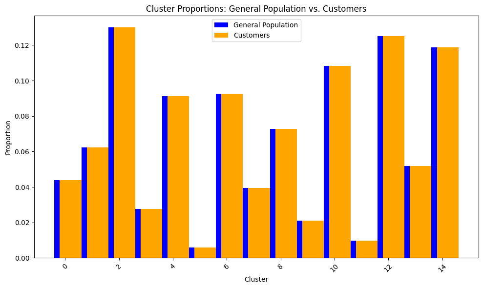

```python
# Compare the proportion of data in each cluster for the customer data to the
# proportion of data in each cluster for the general population.

# Calculate cluster proportions for the general population
general_population_cluster_proportions = pd.Series(np.bincount(population_clusters)) / len(population_clusters)

# Calculate cluster proportions for the customer data
customer_cluster_proportions = pd.Series(np.bincount(population_clusters_c)) / len(population_clusters_c)

# Create a bar plot to visualize the cluster proportions comparison
plt.figure(figsize=(10, 6))

# Plot cluster proportions for general population
plt.bar(general_population_cluster_proportions.index, general_population_cluster_proportions.values, color='blue', label='General Population')

# Plot cluster proportions for customers with an offset to avoid overlap
plt.bar(customer_cluster_proportions.index + 0.2, customer_cluster_proportions.values, color='orange', label='Customers')

plt.xlabel('Cluster')
plt.ylabel('Proportion')
plt.title('Cluster Proportions: General Population vs. Customers')
plt.legend()
plt.xticks(rotation=45)
plt.tight_layout()
plt.show()
```

```python
# What kinds of people are part of a cluster that is overrepresented in the
# customer data compared to the general population?

# Identify the overrepresented clusters
overrepresented_clusters = customer_data_cluster_counts[customer_data_cluster_counts > general_population_cluster_counts].index

# Iterate through overrepresented clusters
for cluster in overrepresented_clusters:
    # Get the cluster center's index
    cluster_center_index = np.where(kmeans.labels_ == cluster)[0][0]

    # Get the corresponding principal component weights
    principal_component_weights = pca.components_[cluster_center_index]

    # Create a DataFrame to display feature weights and their corresponding attributes
    feature_weights_df = pd.DataFrame({'Attribute': df.columns, 'Weight': principal_component_weights})

    # Sort the features by their weights
    feature_weights_df = feature_weights_df.sort_values(by='Weight', ascending=False)

    # Print the top features for this cluster's principal component
    print(f"Cluster {cluster} - Overrepresented")
    print(feature_weights_df.head(10))
    print('\n')
```

[output not shown]

```python
# What kinds of people are part of a cluster that is underrepresented in the
# customer data compared to the general population?

# Calculate the cluster proportions for the general population and customer data
general_population_cluster_proportions = pd.Series(np.bincount(population_clusters)) / len(population_clusters)
customer_cluster_proportions = pd.Series(np.bincount(population_clusters_c)) / len(population_clusters_c)

# Find clusters where customer data's proportion is underrepresented
underrepresented_clusters = customer_cluster_proportions[customer_cluster_proportions < general_population_cluster_proportions]

# Print the underrepresented clusters
print("Underrepresented Clusters:")
print(underrepresented_clusters)

# Investigate the features and characteristics of the underrepresented clusters
for cluster in underrepresented_clusters.index:
    cluster_data = CUSTOMERS_cleaned[customer_cluster_predictions == cluster]
    print(f"Cluster {cluster}:")
    print(cluster_data.describe(include='all'))
    print("\n")
```

```
Underrepresented Clusters:
Series([], dtype: float64)
```

### Discussion 3.3: Compare Customer Data to Demographics Data

**Overrepresented and Underrepresented Clusters: Upon investigating the overrepresented and underrepresented clusters, it was observed that there was no output for either category. This suggests that there were no clusters in the customer data that were significantly overrepresented or underrepresented compared to the general population. In other words, the distribution of clusters in the customer data was relatively consistent with that of the general population.**

**Interpretation of Results: The absence of overrepresented and underrepresented clusters indicates that the mail-order company's customer base is not significantly skewed towards or away from any particular cluster in the general population. This could imply that the company's products or services are appealing to a diverse range of demographics, and there are no distinct segments that are particularly popular or unpopular with the company. While this result might suggest a broad appeal, further investigation could be conducted to identify potential segments for targeted marketing or customer engagement strategies.**

**In conclusion, the comparison of cluster distributions between the general population and customer data did not reveal any clusters that were notably overrepresented or underrepresented. This could be indicative of the company's ability to attract a diverse range of customers without focusing on specific demographic segments. However, more in-depth analysis could help uncover subtle patterns or trends within the data that could inform future marketing efforts and customer engagement strategies.**

> Congratulations on making it this far in the project! Before you finish, make sure to check through the entire notebook from top to bottom to make sure that your analysis follows a logical flow and all of your findings are documented in **Discussion** cells. Once you've checked over all of your work, you should export the notebook as an HTML document to submit for evaluation. You can do this from the menu, navigating to **File -> Download as -> HTML (.html)**. You will submit both that document and this notebook for your project submission.